# Distributions

2023-08-02

# AC12

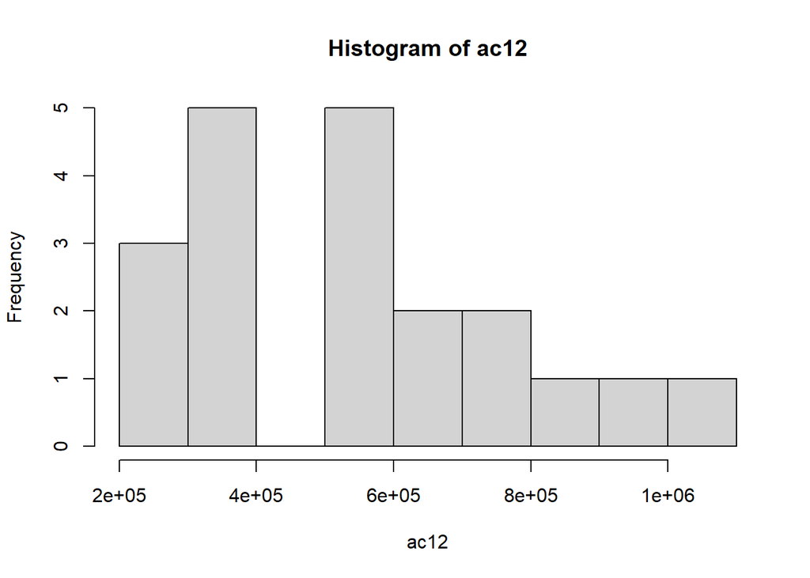

```r
ac12<-rev(b$ac1+b$ac2)
hist(ac12)
```

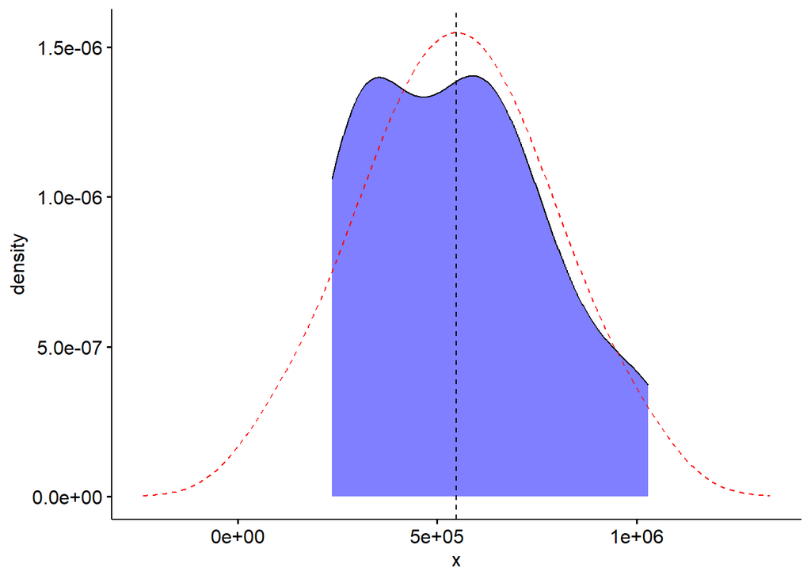

```r
ggdensity(ac12, add='mean', fill='blue')+stat_overlay_normal_density(color = "red", linetype = "dashed")
```

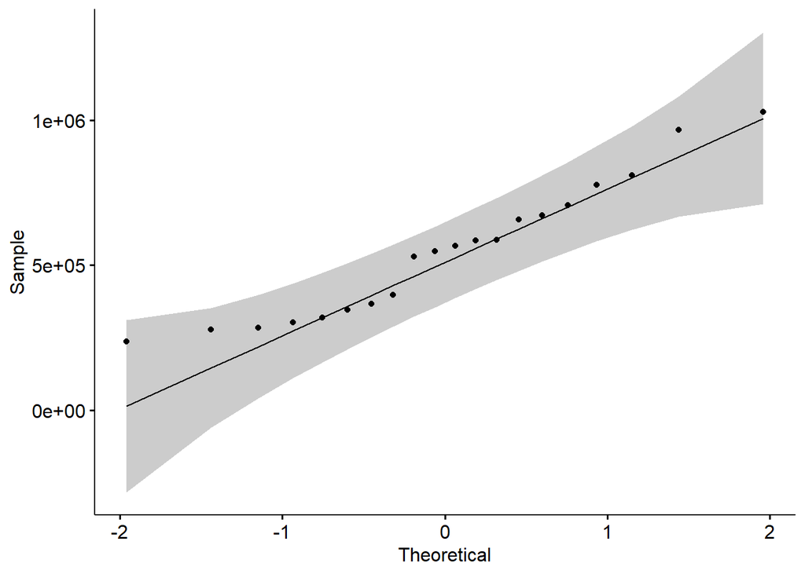

```r
ggqqplot(ac12)
```

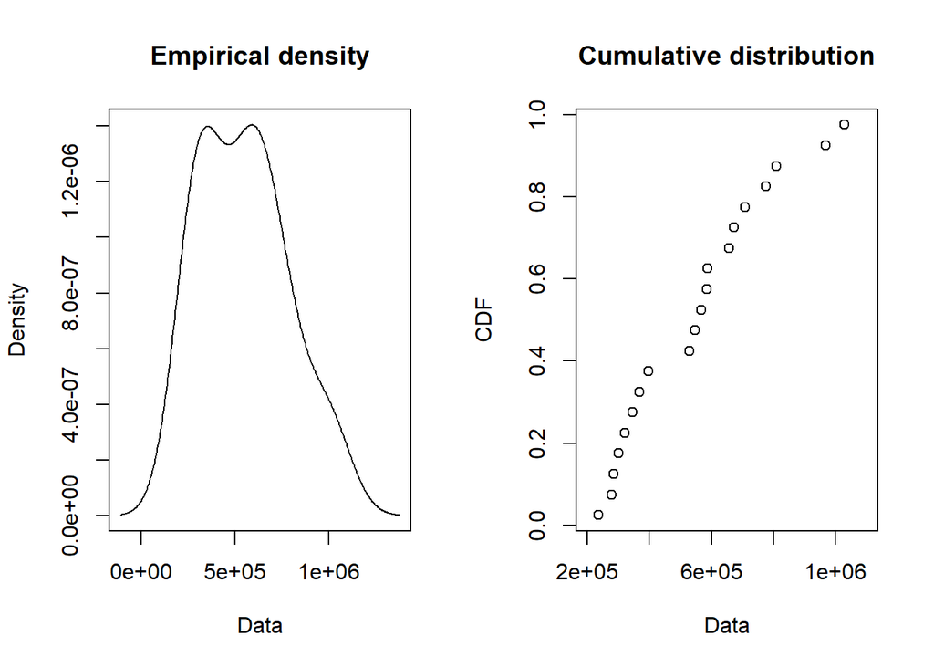

```r
plotdist(ac12, histo= FALSE, demp = TRUE)
```

```r
shapiro.test(ac12)
```

```
##
##  Shapiro-Wilk normality test
##
## data:  ac12
## W = 0.93915, p-value = 0.231
```

```r
ks.test(ac12,"pnorm")
```

```
##
##  Exact one-sample Kolmogorov-Smirnov test
##
## data:  ac12
## D = 1, p-value < 2.2e-16
## alternative hypothesis: two-sided
```

```r
ad.test(ac12)
```

```
##
##  Anderson-Darling normality test
##
## data:  ac12
## A = 0.40143, p-value = 0.3276
```

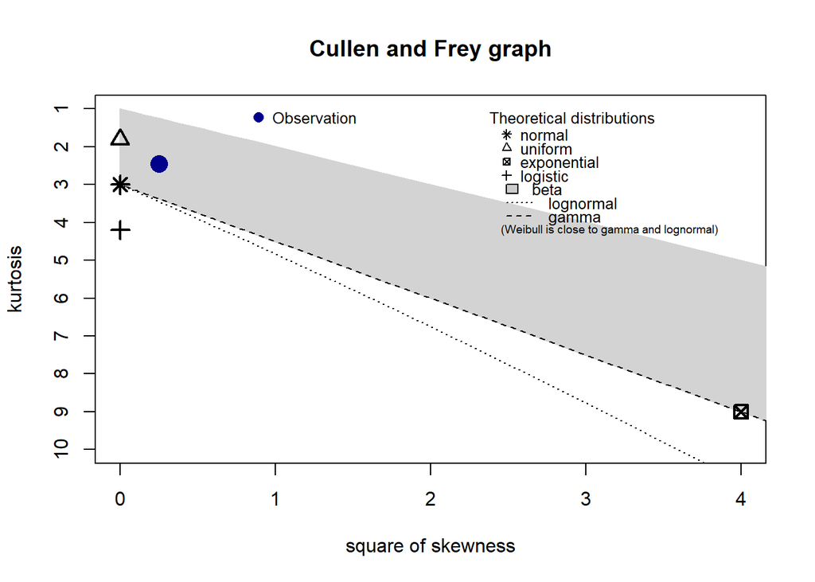

```
## summary statistics
## ------
## min:  236519   max:  1029846
## median:  556784.5
## mean:  548453.8
## estimated sd:  233237.8
## estimated skewness:  0.5017119
## estimated kurtosis:  2.445058
```

```r
descdist(data =ac12, discrete =FALSE)
```

```r
S <- sqrt(mean((ac12 - min(ac12))^2))
sqrt(6) / pi * S / ((sqrt(mean((ac12 - min(ac12))^2)))^2)
```

```
## [1] 2.020026e-06
```

```r
init <- list(shape = sqrt(6) / pi * S / ((sqrt(mean((ac12 - min(ac12))^2)))^2), scale = sqrt(mean((ac12 - min(ac12))^2)), thres = min(ac12))
wac12= fitdist(ac12,"weibull3",method="mge",start =init)
gofstat(wac12,fitnames=c("weibull3"))
```

```
## Goodness-of-fit statistics
##                                weibull3
## Kolmogorov-Smirnov statistic 0.10836319
## Cramer-von Mises statistic   0.04211174
## Anderson-Darling statistic   0.30184670
##
## Goodness-of-fit criteria
##                                weibull3
## Akaike's Information Criterion 554.5162
## Bayesian Information Criterion 557.5034
```

```r
bc12<- boxcoxnc(ac12, method = "mle", lambda = seq(-2,2,0.0001))
```

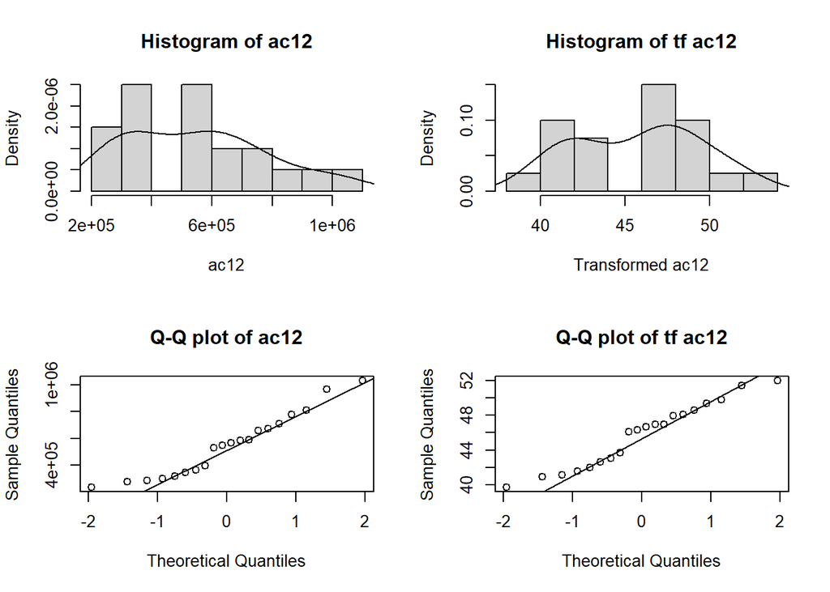

```
##
##   Box-Cox power transformation
## ----------------------------------------------------------------------------
##    data : ac12
##
##
##    lambda.hat : 0.1621
##
##
##   Shapiro-Wilk normality test for transformed data (alpha = 0.05)
## -----------------------------------------------------------------------
##    statistic  : 0.9521511
##
##    p.value    : 0.400927
##
##   Result     : Transformed data are normal.
## ----------------------------------------------------------------------------
```

```r
#bc12$lambda.hat
shapiro.test(bc12$tf.data)#transformed data normality
```

```
##
##  Shapiro-Wilk normality test
##
## data:  bc12$tf.data
## W = 0.95215, p-value = 0.4009
```

#### Conclusion: AC12 ~ 3-parameter weibull (shape=1,27236, scale=341964, thres=229170)

#### les tests de normalité de AC 12 sont bons AC12 ~ N(mean=548453.8,sd=227332.1) (could be considered).

#### La transformation de BoxCox n’est pas necessaire puisque la variable AC12 est presque normale.

# AC3

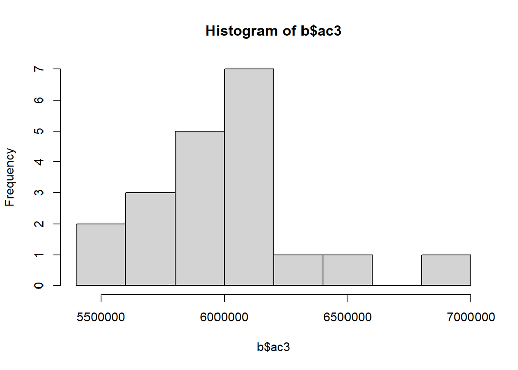

```r
hist(b$ac3)
```

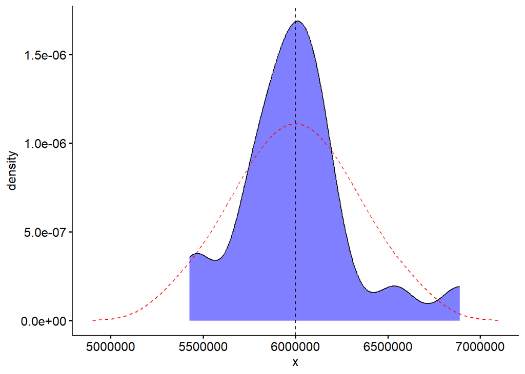

```r
ggdensity(b$ac3, add='mean', fill='blue')+stat_overlay_normal_density(color = "red", linetype = "dashed")
```

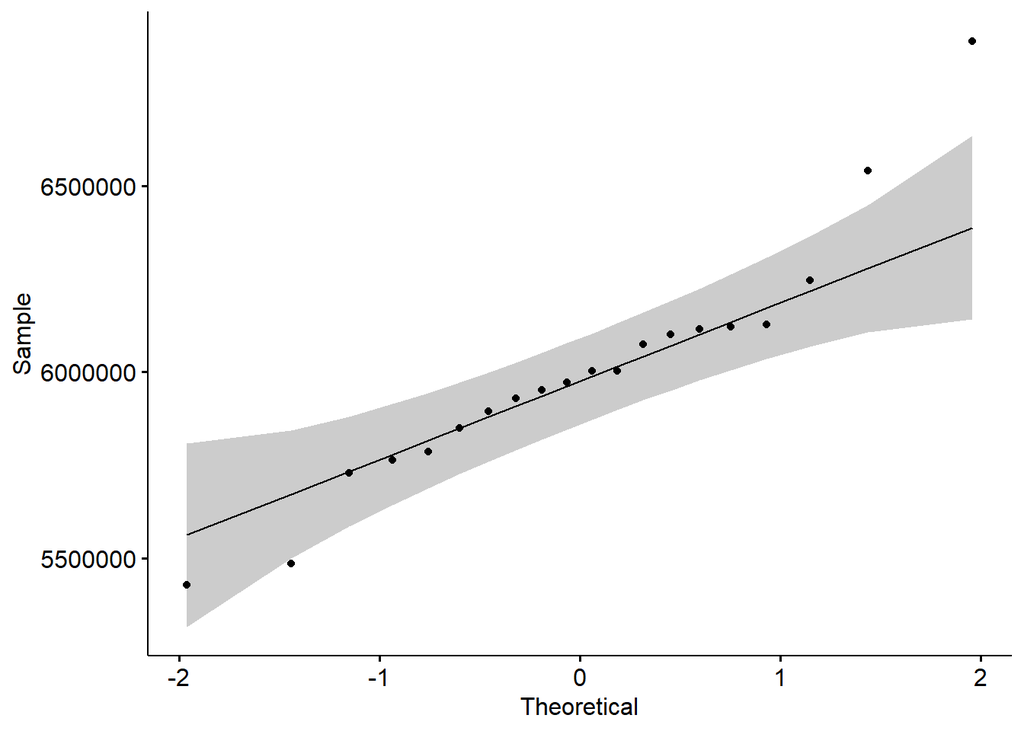

```r
ggqqplot(b$ac3)
```

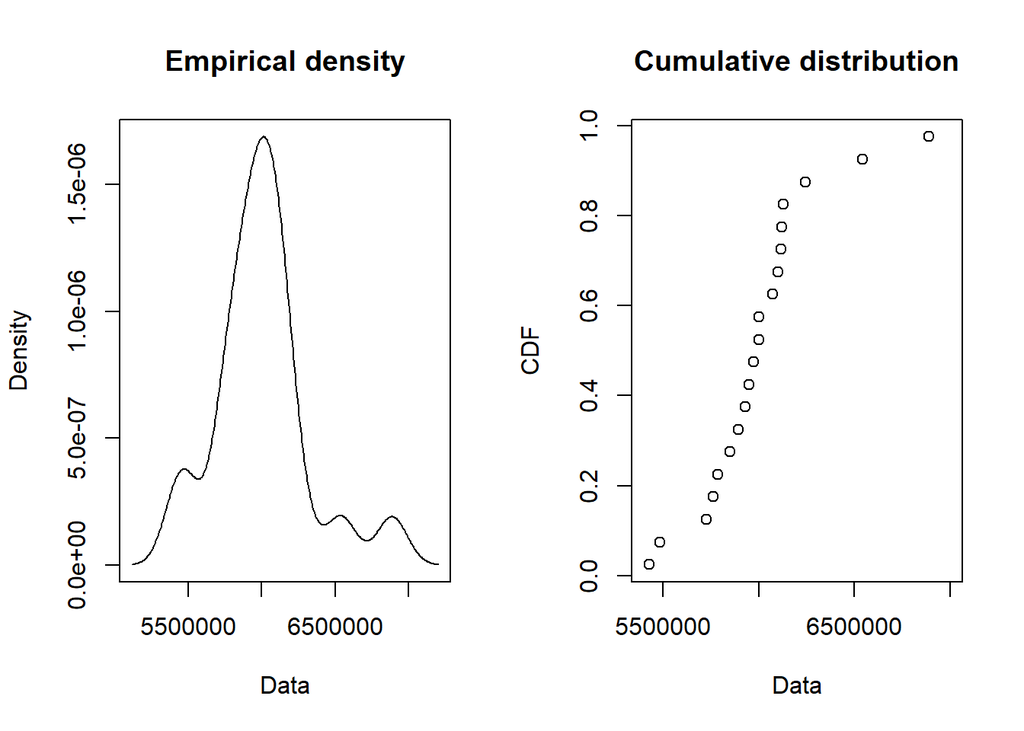

```r
plotdist(b$ac3, histo= FALSE, demp = TRUE)
```

```r
shapiro.test(b$ac3)
```

```
##
##  Shapiro-Wilk normality test
##
## data:  b$ac3
## W = 0.92605, p-value = 0.1296
```

```r
ad.test(b$ac3)
```

```
##
##  Anderson-Darling normality test
##
## data:  b$ac3
## A = 0.59098, p-value = 0.1088
```

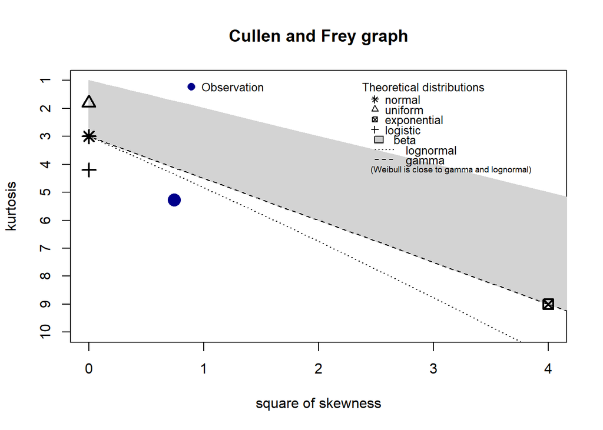

```
## summary statistics
## ------
## min:  5426908   max:  6889784
## median:  5986835
## mean:  6000196
## estimated sd:  325833.2
## estimated skewness:  0.8620727
## estimated kurtosis:  5.270517
```

```r
descdist(data =b$ac3, discrete =FALSE)
```

```r
lac3= fitdist(b$ac3,"logis")
llac3= fitdist(log(b$ac3),"logis")
l3<-list(lac3,llac3)
print(l3)
```

```
## [[1]]
## Fitting of the distribution ' logis ' by maximum likelihood
## Parameters:
##           estimate Std. Error
## location 5981982.9          0
## scale     164463.4          0
##
## [[2]]
## Fitting of the distribution ' logis ' by maximum likelihood
## Parameters:
##             estimate  Std. Error
## location 15.60390094 0.010322763
## scale     0.02727311 0.005241308
```

#### le log(AC3) ~ logistic ($\mu$:location = 15,60390, s:scale= 0,02728), ceci est équivalent à dire AC3 ~ log-logistic ($\mu$:location = 15,60390, s:scale= 0,02728).

#### On pourra aussi appliquer la transformation de BoxCox ; $\lambda=-3$ (minitab) sur la variable AC3 pour la normaliser.

## AC45

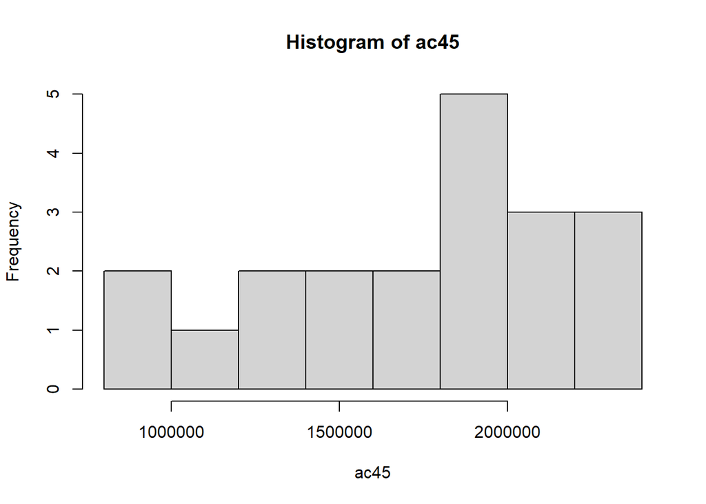

```r
ac45<-b$ac4+b$ac5
hist(ac45)
```

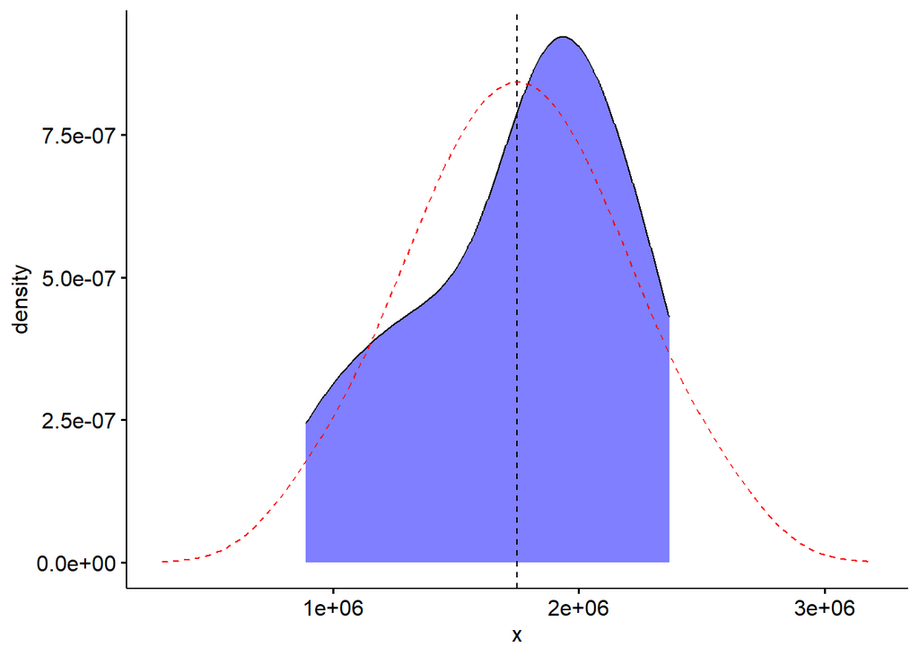

```r
ggdensity(ac45, add='mean', fill='blue')+stat_overlay_normal_density(color = "red", linetype = "dashed")
```

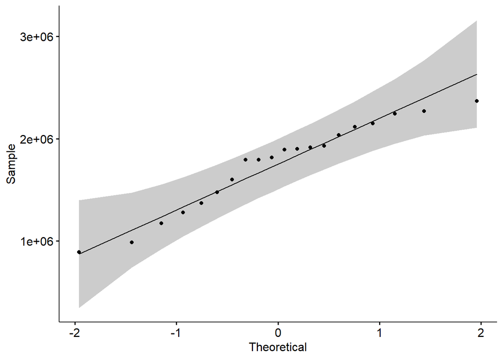

```r
ggqqplot(ac45)
```

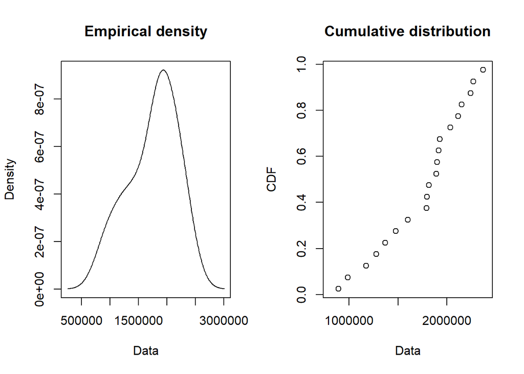

```r
plotdist(ac45, histo= FALSE, demp = TRUE)
```

```r
shapiro.test(ac45)
```

```
##
##  Shapiro-Wilk normality test
##
## data:  ac45
## W = 0.94216, p-value = 0.2634
```

```r
ad.test(ac45)
```

```
##
##  Anderson-Darling normality test
##
## data:  ac45
## A = 0.44539, p-value = 0.2546
```

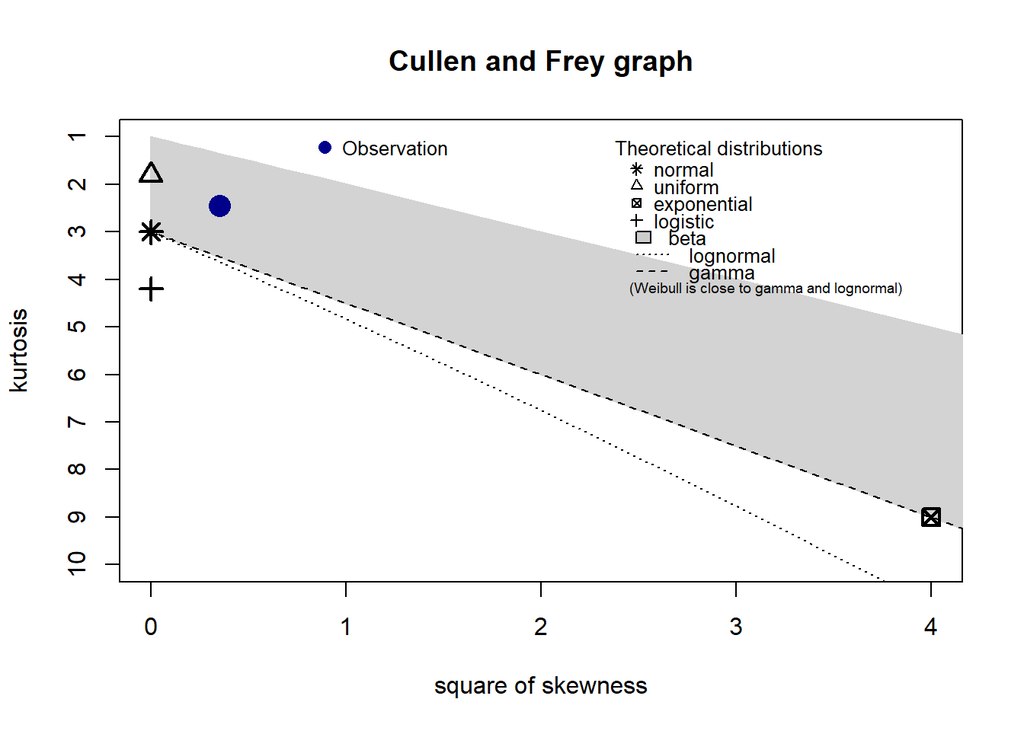

```
## summary statistics
## ------
## min:  890448   max:  2368299
## median:  1854344
## mean:  1749494
## estimated sd:  428881.4
## estimated skewness:  -0.5936062
## estimated kurtosis:  2.452588
```

```r
descdist(data =ac45, discrete =FALSE)
```

```r
S <- sqrt(mean((ac45 - min(ac45))^2))
sqrt(6) / pi * S / ((sqrt(mean((ac45 - min(ac45))^2)))^2)
```

```
## [1] 8.161336e-07
```

```r
init45 <- list(shape = sqrt(6) / pi * S / ((sqrt(mean((ac45 - min(ac45))^2)))^2), scale = sqrt(mean((ac45 - min(ac45))^2)), thres = min(ac45))
wac45= fitdist(ac45,"weibull3",method="mge",start =init45)
```

#### Conclusion: AC45 ~ 3-parameter weibull (shape=1359,84798, scale=457094000, thres=-455148000)

#### On pourra aussi appliquer la transformation de BoxCox; $\lambda=2$ (minitab) sur la variable AC3 pour la normaliser.

## AC6

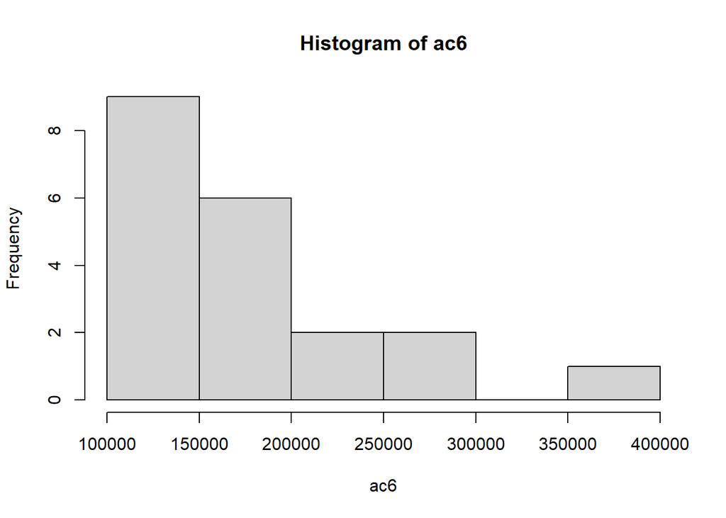

```r
ac6<-b$ac6
hist(ac6)
```

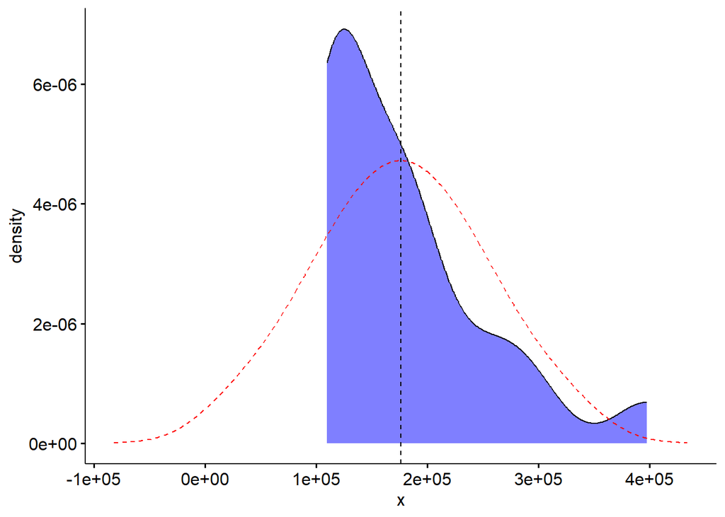

```r
ggdensity(ac6, add='mean', fill='blue')+stat_overlay_normal_density(color = "red", linetype = "dashed")
```

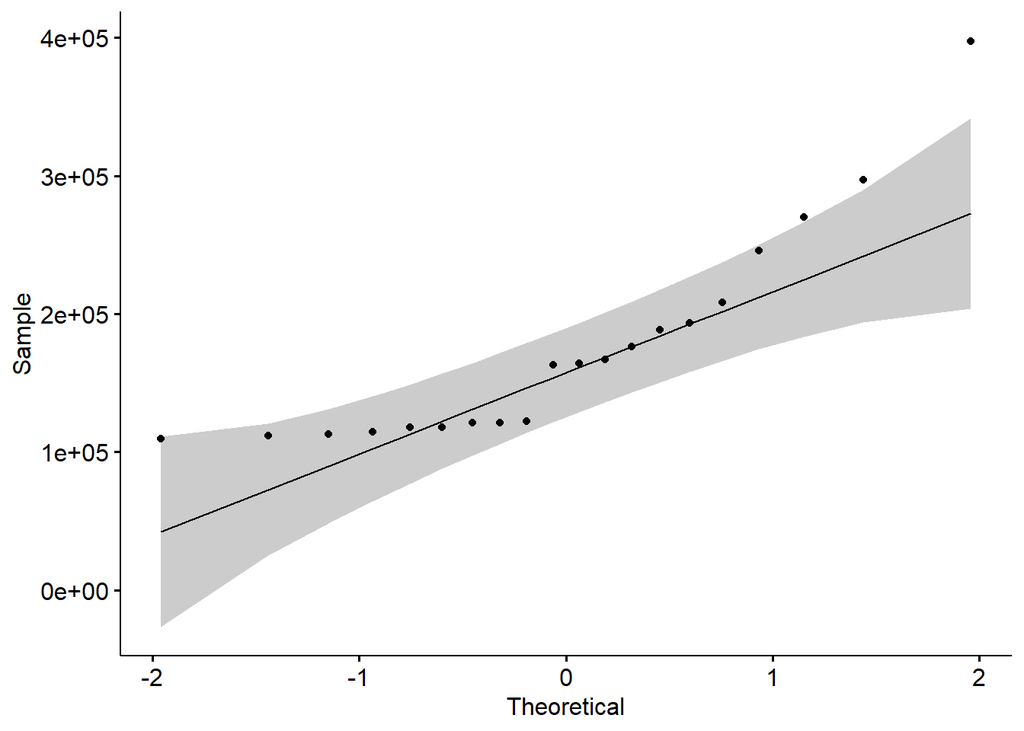

```r
ggqqplot(ac6)
```

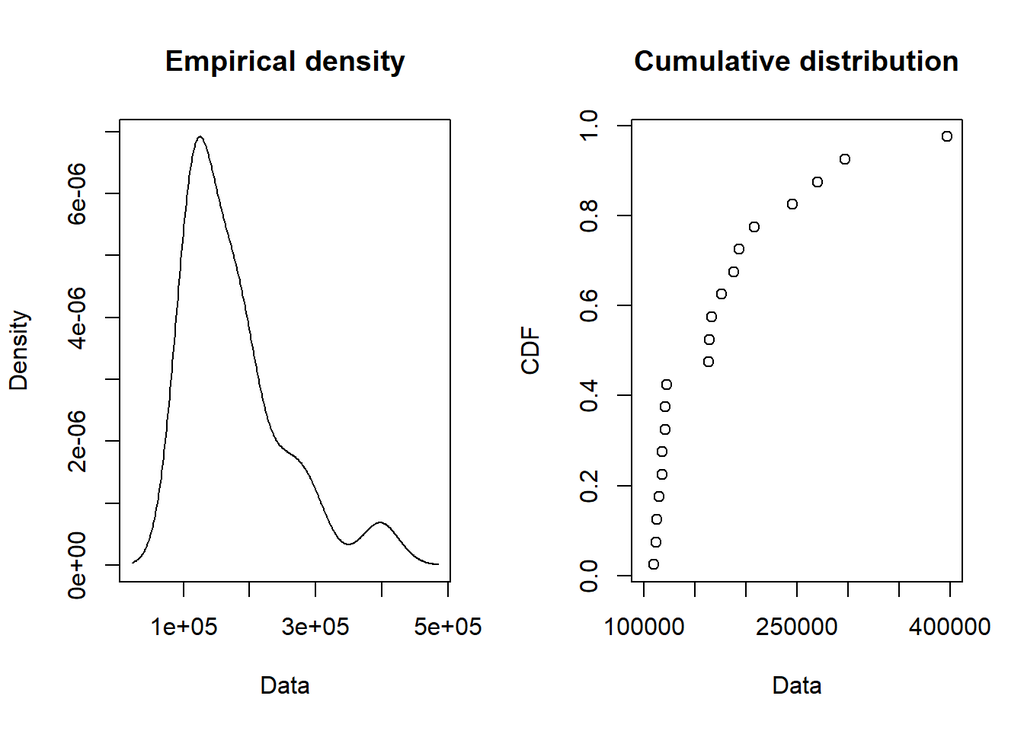

```r
plotdist(ac6, histo= FALSE, demp = TRUE)
```

```r
shapiro.test(ac6)
```

```
##
##  Shapiro-Wilk normality test
##
## data:  ac6
## W = 0.81587, p-value = 0.001505
```

```r
ad.test(ac6)
```

```
##
##  Anderson-Darling normality test
##
## data:  ac6
## A = 1.2419, p-value = 0.002309
```

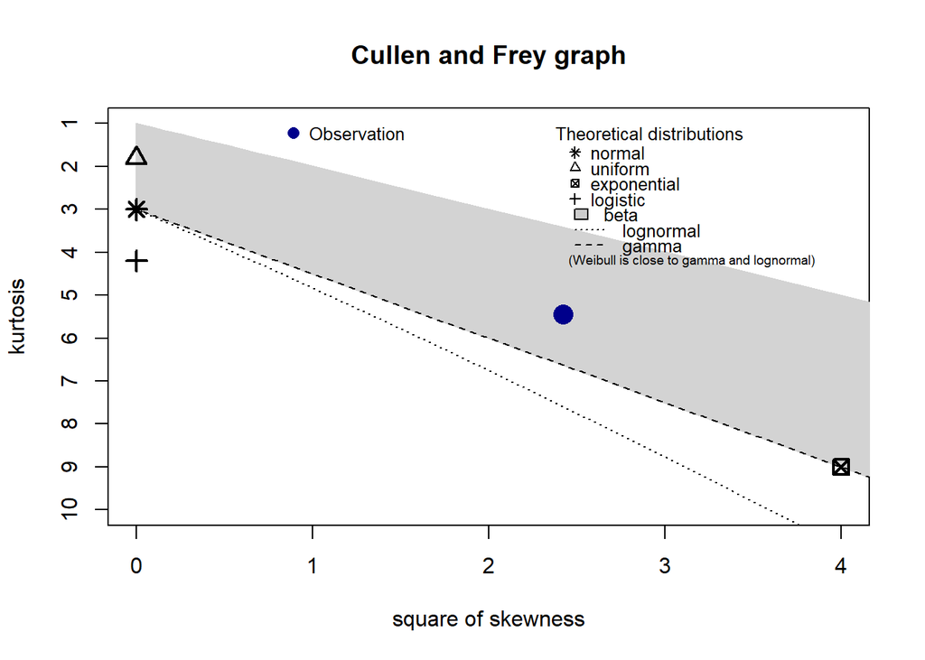

```
## summary statistics
## ------
## min:  109751   max:  397473
## median:  163656.5
## mean:  175978.2
## estimated sd:  76529.36
## estimated skewness:  1.556414
## estimated kurtosis:  5.441778
```

```r
descdist(data =ac6, discrete =FALSE)
```

```r
jtac6<-1.14174 + 0.522007*log( ( ac6 - 109374 ) / ( 424867 - ac6 ) )
shapiro.test(jtac6)
```

```
##
##  Shapiro-Wilk normality test
##
## data:  jtac6
## W = 0.97841, p-value = 0.912
```

#### Conclusion: AC6 ~ 3-parameter weibull (shape=0,82878, scale=61604,88454, thres=107917).

#### On pourra aussi appliquer la transformation de Johnson sur la variable AC6 pour la normaliser, les données transformées sont presque normales. On appliquera la formule suivante sur les données :1.14174 + 0.522007*log( ( ac6 - 109374 ) / ( 424867 - ac6 ) ).

## AC7

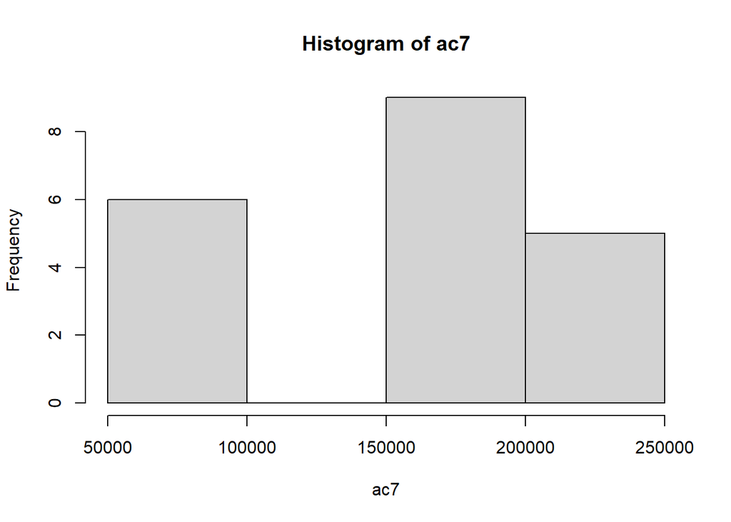

```r
ac7<-b$ac7
hist(ac7)
```

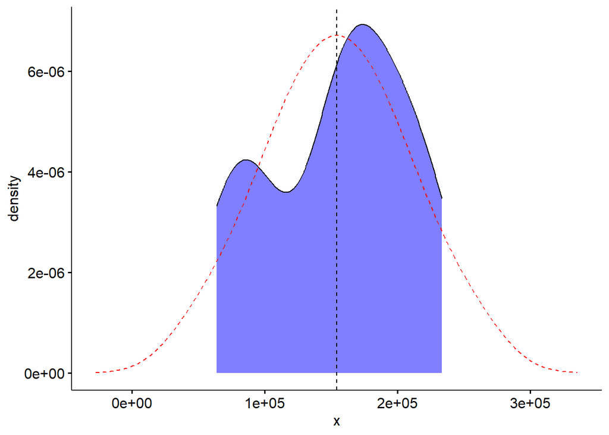

```r
ggdensity(ac7, add='mean', fill='blue')+stat_overlay_normal_density(color = "red", linetype = "dashed")
```

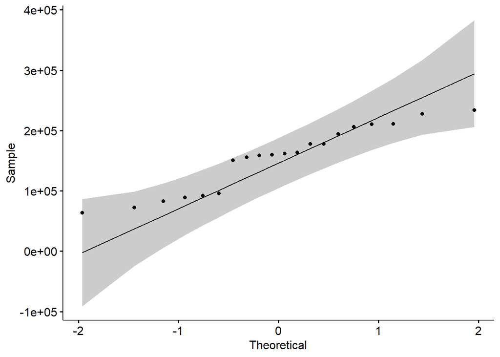

```r
ggqqplot(ac7)
```

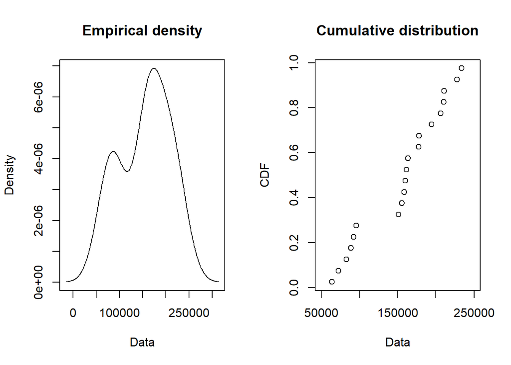

```r
plotdist(ac7, histo= FALSE, demp = TRUE)
```

```r
shapiro.test(ac7)
```

```
##
##  Shapiro-Wilk normality test
##
## data:  ac7
## W = 0.92034, p-value = 0.1006
```

```r
ad.test(ac7)
```

```
##
##  Anderson-Darling normality test
##
## data:  ac7
## A = 0.63063, p-value = 0.08597
```

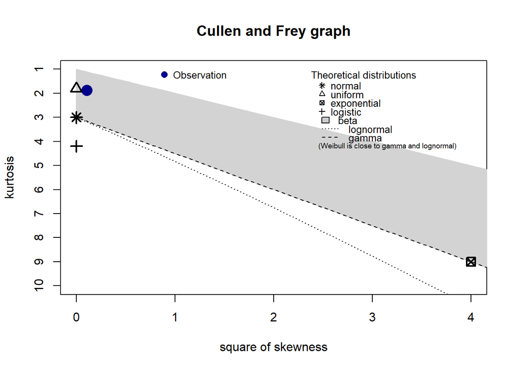

```
## summary statistics
## ------
## min:  63897   max:  233528
## median:  160718.5
## mean:  154204
## estimated sd:  53841.58
## estimated skewness:  -0.3262634
## estimated kurtosis:  1.875486
```

```r
descdist(data =ac7, discrete =FALSE)
```

```r
jtac7<-0.0375501+0.478592*log((ac7-61348.7)/(236502-ac7))
shapiro.test(jtac7)
```

```
##
##  Shapiro-Wilk normality test
##
## data:  jtac7
## W = 0.97184, p-value = 0.7932
```

#### On n’est pas arrivé à ajuster la variable AC7 en utilisant les distributions usuelles. La meilleure solution est d’appliquer la transformation de Johnson sur la variable AC7 pour la normaliser. On appliquera la formule suivante sur les données :0.0375501+0.478592*log((ac7-61348.7)/(236502-ac7)) (minitab).

## PA12

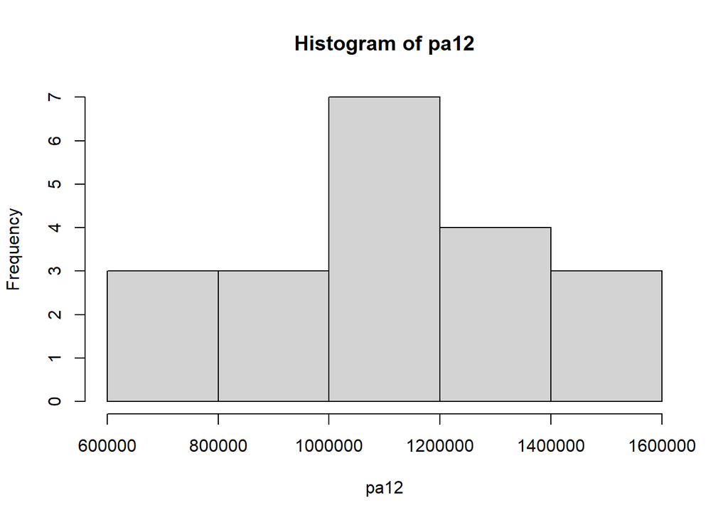

```r
pa12<-b$pa1+b$pa2
hist(pa12)
```

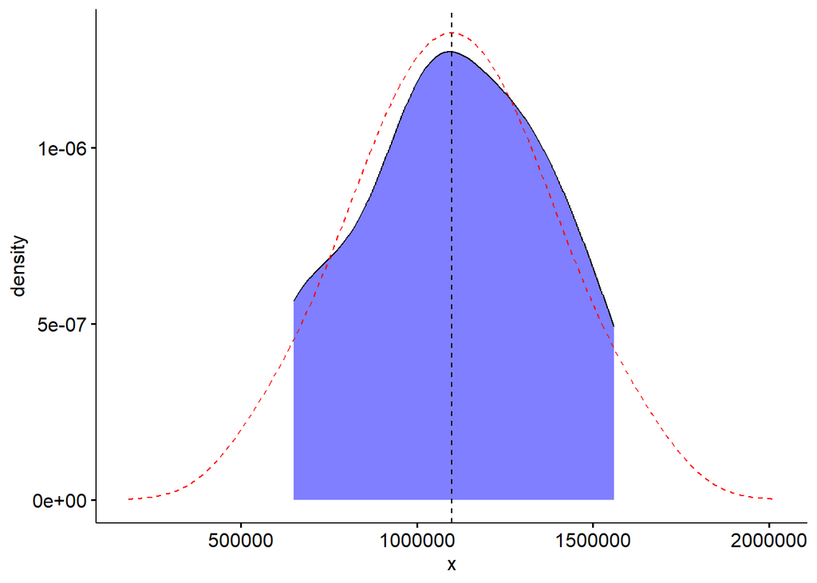

```r
ggdensity(pa12, add='mean', fill='blue')+stat_overlay_normal_density(color = "red", linetype = "dashed")
```

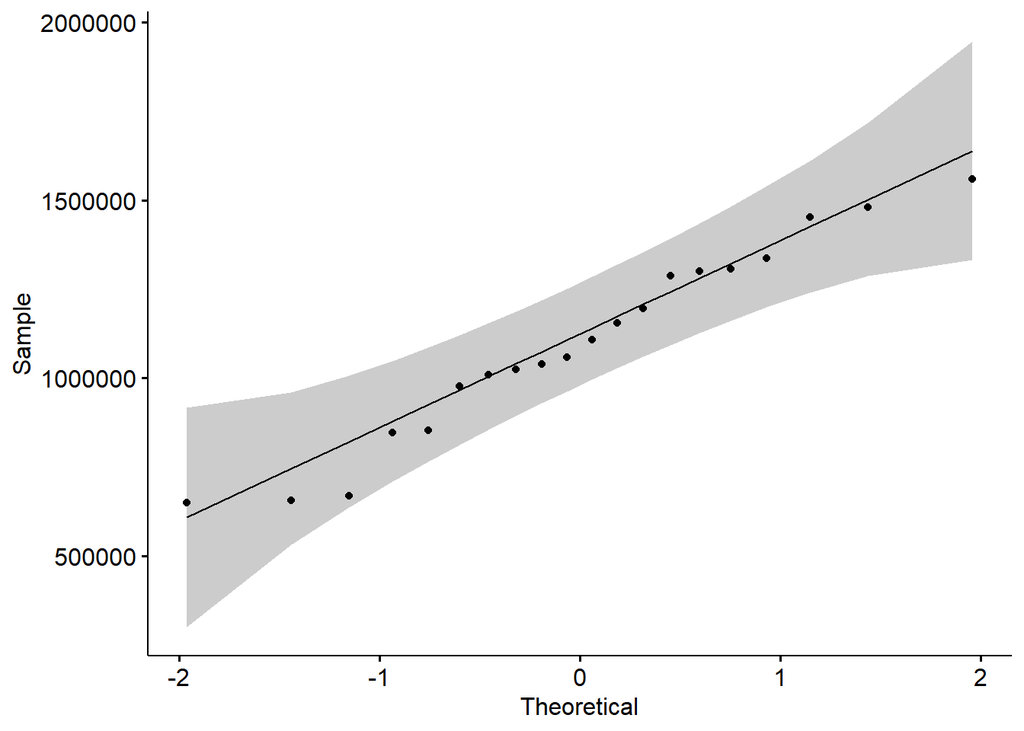

```r
ggqqplot(pa12)
```

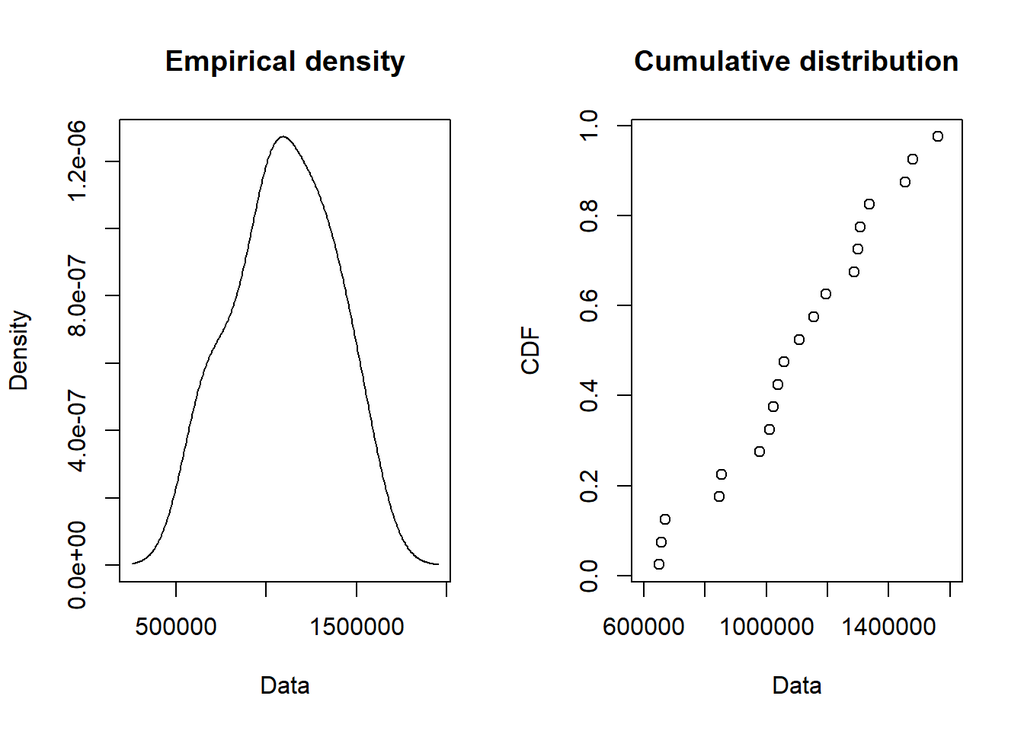

```r
plotdist(pa12, histo= FALSE, demp = TRUE)
```

```r
shapiro.test(pa12)
```

```
##
##  Shapiro-Wilk normality test
##
## data:  pa12
## W = 0.96018, p-value = 0.5475
```

```r
ad.test(pa12)
```

```
##
##  Anderson-Darling normality test
##
## data:  pa12
## A = 0.23982, p-value = 0.7441
```

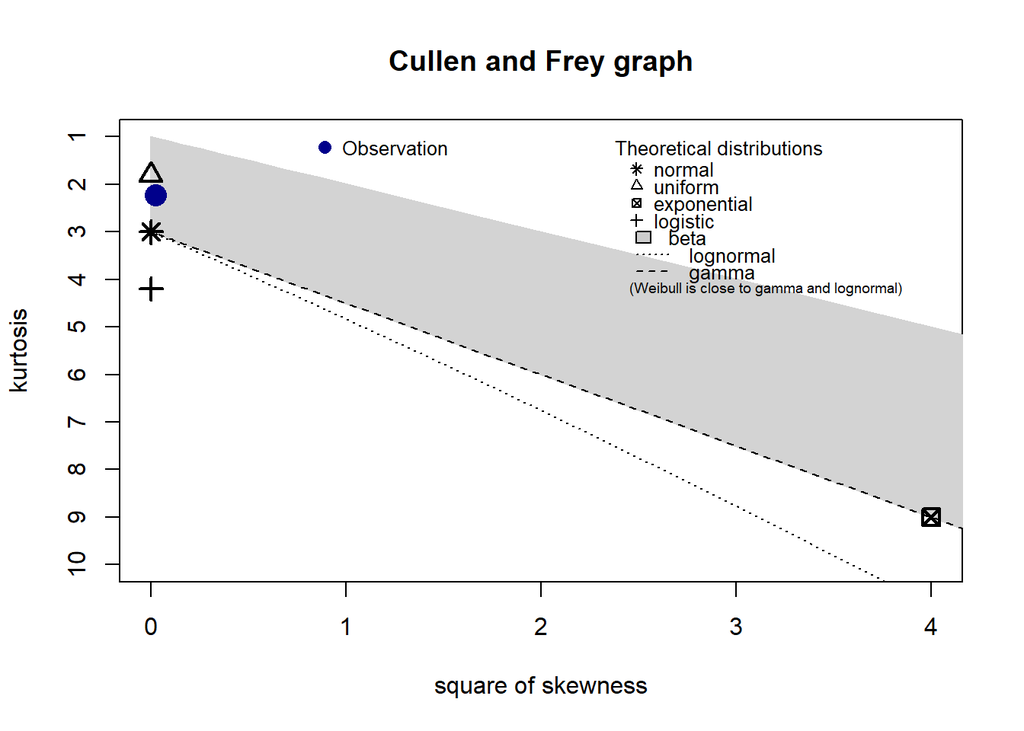

```
## summary statistics
## ------
## min:  649379   max:  1559931
## median:  1082465
## mean:  1098202
## estimated sd:  272373.1
## estimated skewness:  -0.1496572
## estimated kurtosis:  2.226591
```

```r
descdist(data =pa12, discrete =FALSE)
```

```r
npa12=fitdist(pa12,"norm")
```

#### les tests de normalité de PA12 sont très bons PA12 ~ N(mean=1098202,sd=265476)

## PA3

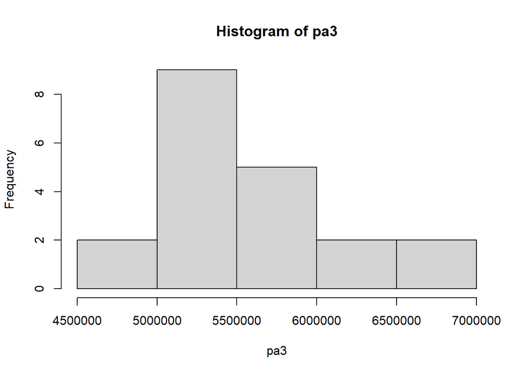

```r
pa3<-b$pa3
hist(pa3)
```

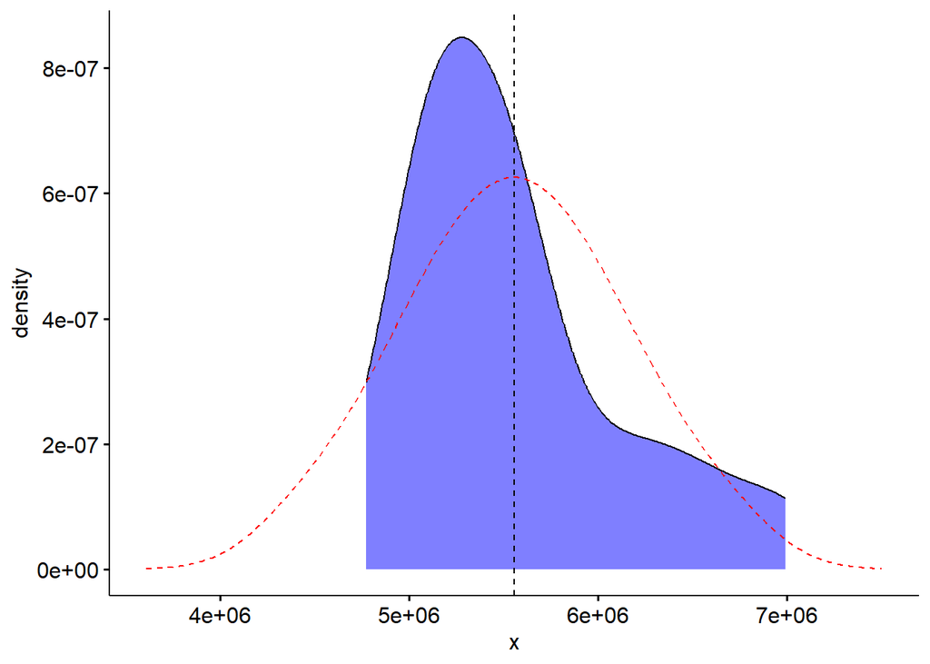

```r
ggdensity(pa3, add='mean', fill='blue')+stat_overlay_normal_density(color = "red", linetype = "dashed")
```

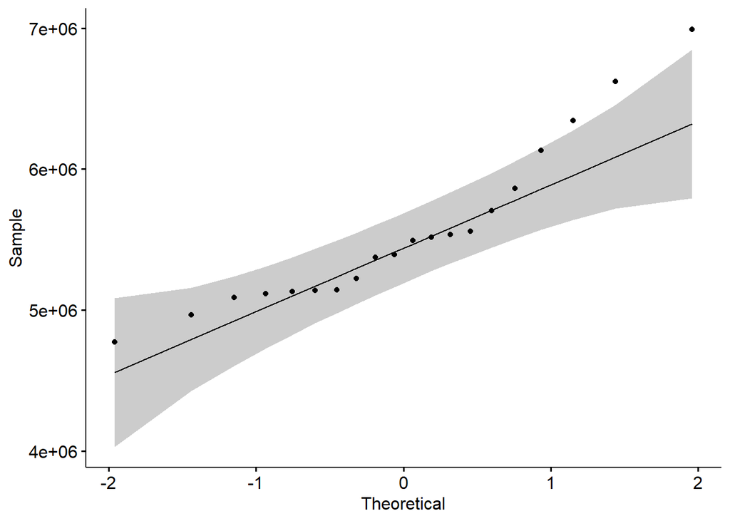

```r
ggqqplot(pa3)
```

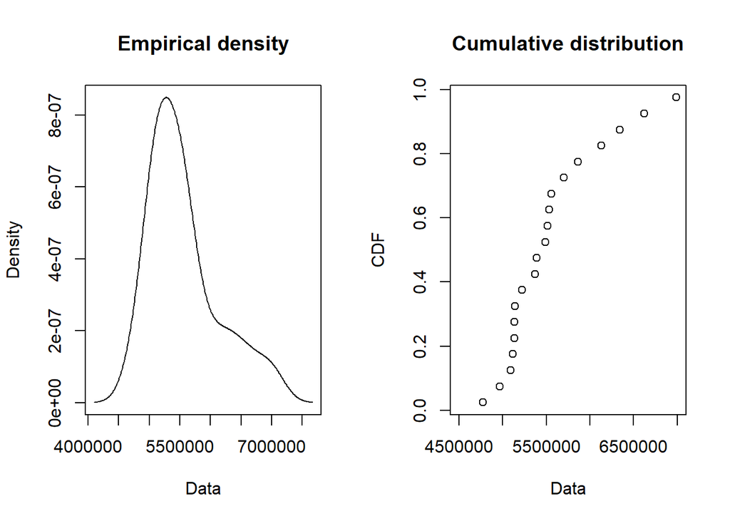

```r
plotdist(pa3, histo= FALSE, demp = TRUE)
```

```r
shapiro.test(pa3)
```

```
##
##  Shapiro-Wilk normality test
##
## data:  pa3
## W = 0.89833, p-value = 0.03838
```

```r
ad.test(pa3)
```

```
##
##  Anderson-Darling normality test
##
## data:  pa3
## A = 0.80323, p-value = 0.03091
```

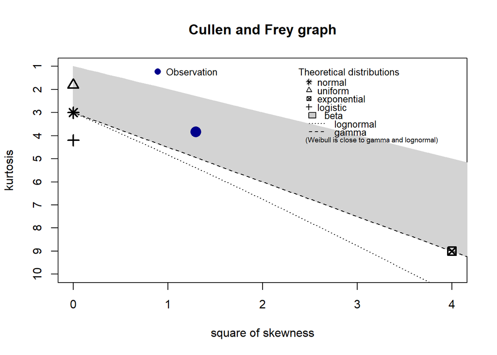

```
## summary statistics
## ------
## min:  4771687   max:  6990819
## median:  5442339
## mean:  5554969
## estimated sd:  577454.7
## estimated skewness:  1.137885
## estimated kurtosis:  3.833412
```

```r
descdist(data =pa3, discrete =FALSE)
```

```r
jtpa3<-pa3-1.88580 +1.37143 * asinh((pa3-4805082) / 299124)
shapiro.test(jtpa3)
```

```
##
##  Shapiro-Wilk normality test
##
## data:  jtpa3
## W = 0.89833, p-value = 0.03838
```

## PA4

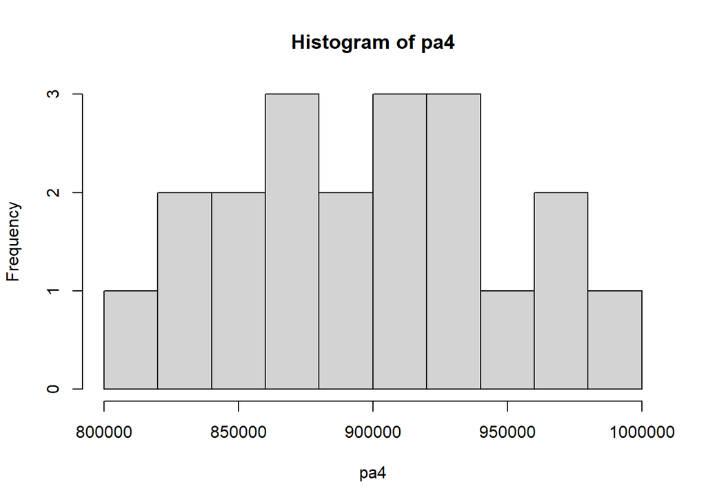

```r
pa4<-b$pa4
hist(pa4)
```

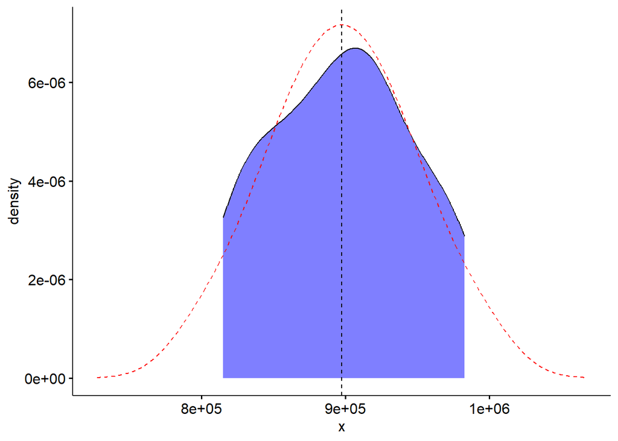

```r
ggdensity(pa4, add='mean', fill='blue')+stat_overlay_normal_density(color = "red", linetype = "dashed")
```

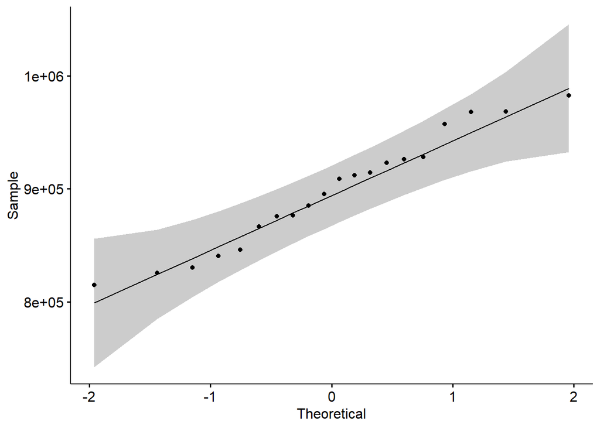

```r
ggqqplot(pa4)
```

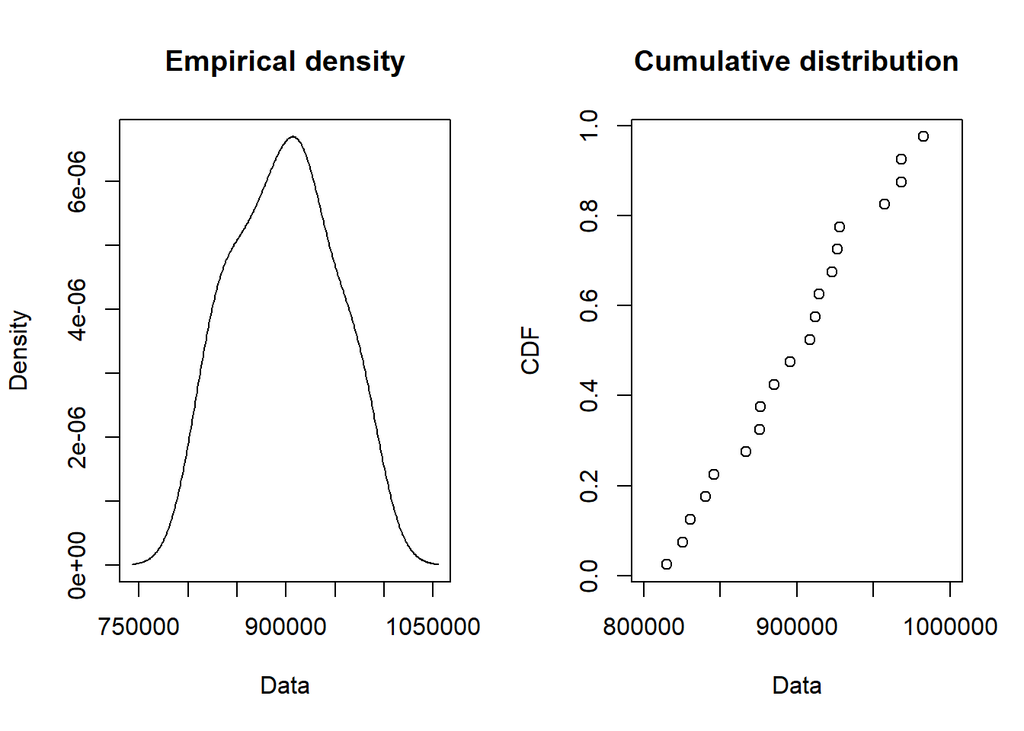

```r
plotdist(pa4, histo= FALSE, demp = TRUE)
```

```r
shapiro.test(pa4)
```

```
##
##  Shapiro-Wilk normality test
##
## data:  pa4
## W = 0.9617, p-value = 0.5784
```

```r
ad.test(pa4)
```

```
##
##  Anderson-Darling normality test
##
## data:  pa4
## A = 0.23274, p-value = 0.768
```

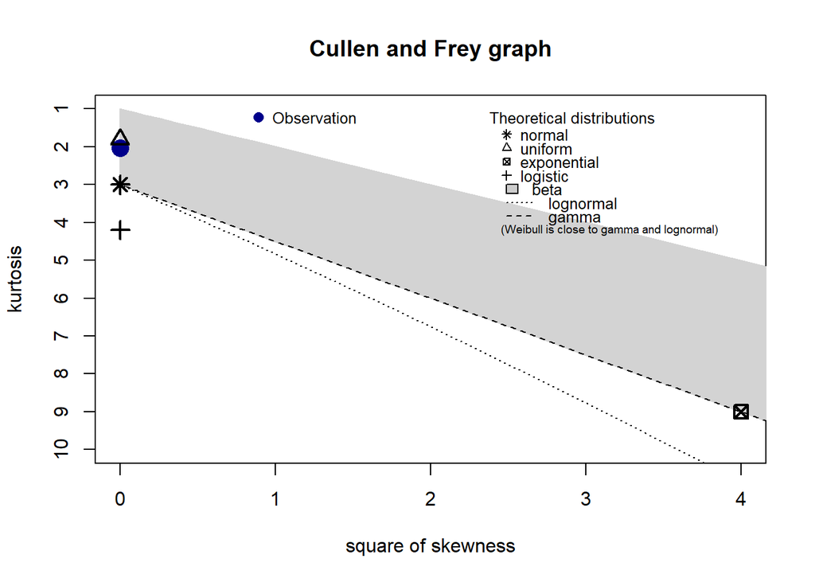

```
## summary statistics
## ------
## min:  815005   max:  982621
## median:  902076.5
## mean:  897246
## estimated sd:  50410.49
## estimated skewness:  0.01884644
## estimated kurtosis:  2.030722
```

```r
descdist(data =pa4, discrete =FALSE)
```

```r
npa4=fitdist(pa4,"norm")
```

#### les tests de normalité de PA4 sont très bons PA4 ~ N(mean= 897246 ,sd=49134)

## PA5

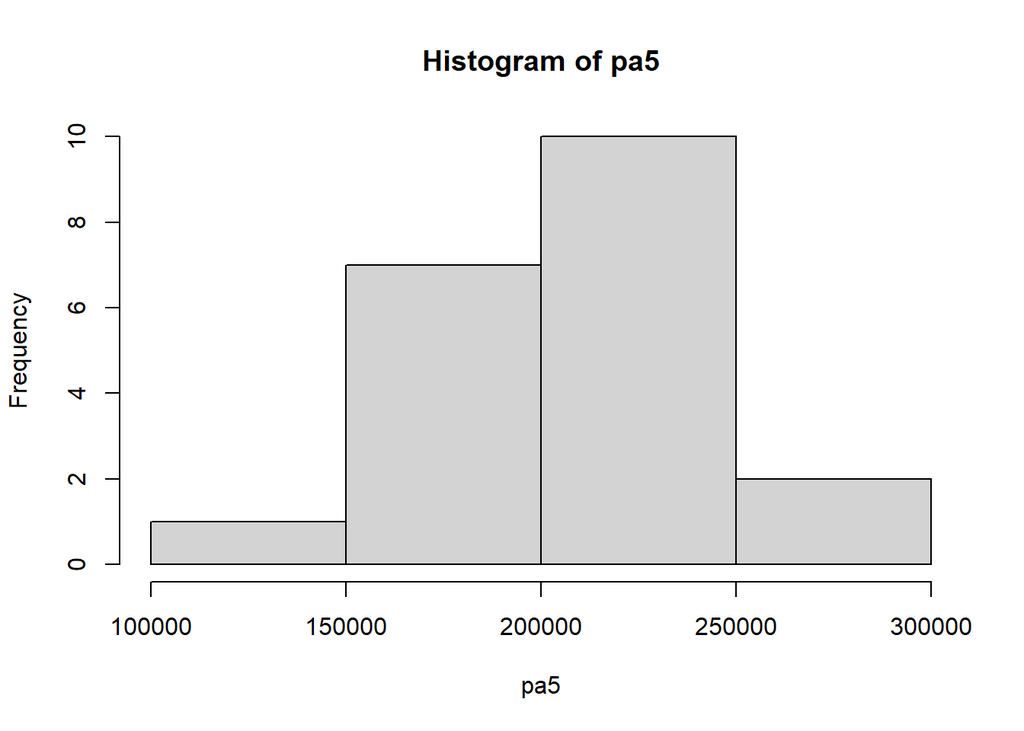

```r
pa5<-b$pa5
hist(pa5)
```

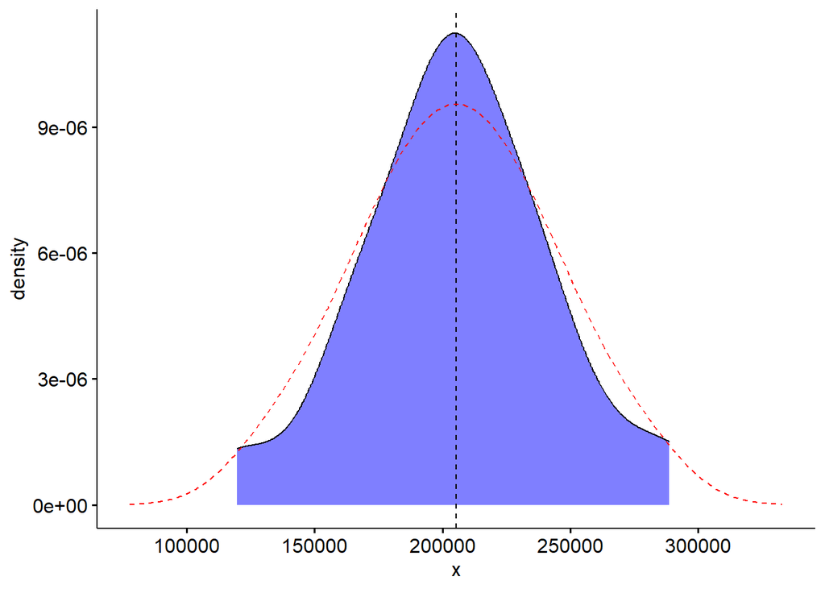

```r
ggdensity(pa5, add='mean', fill='blue')+stat_overlay_normal_density(color = "red", linetype = "dashed")
```

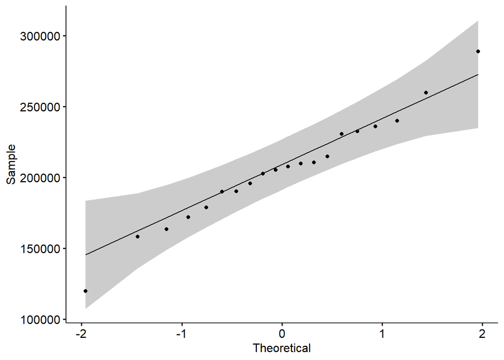

```r
ggqqplot(pa5)
```

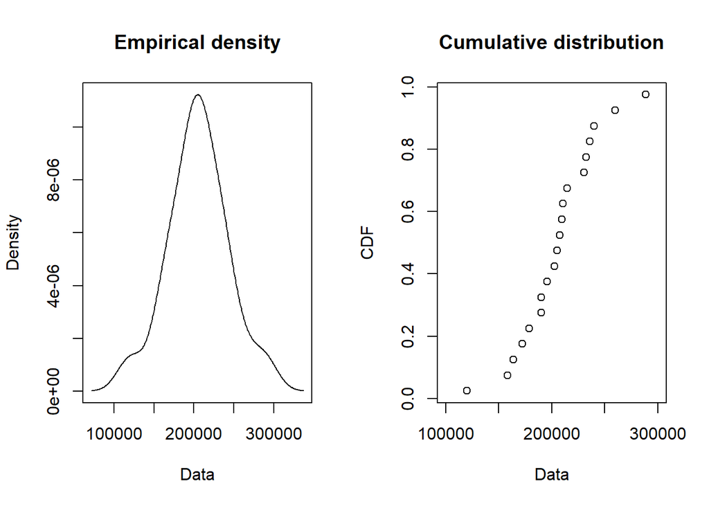

```r
plotdist(pa5, histo= FALSE, demp = TRUE)
```

```r
shapiro.test(pa5)
```

```
##
##  Shapiro-Wilk normality test
##
## data:  pa5
## W = 0.9859, p-value = 0.9865
```

```r
ad.test(pa5)
```

```
##
##  Anderson-Darling normality test
##
## data:  pa5
## A = 0.19708, p-value = 0.8717
```

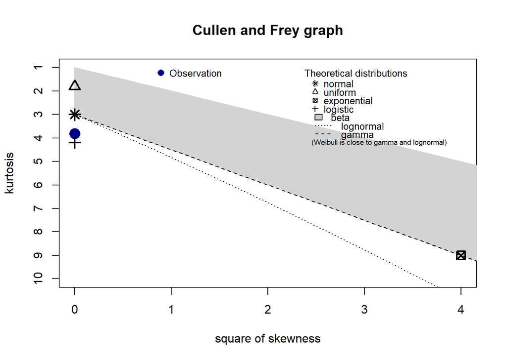

```
## summary statistics
## ------
## min:  119823   max:  288729
## median:  206383.5
## mean:  205304.5
## estimated sd:  37851.95
## estimated skewness:  -0.01620577
## estimated kurtosis:  3.813982
```

```r
descdist(data =pa5, discrete =FALSE)
```

```r
npa5=fitdist(pa5,"norm")
```

#### les tests de normalité de PA5 sont très bons PA5 ~ N(mean= 205305 ,sd=36894)

# Total des passifs: TP

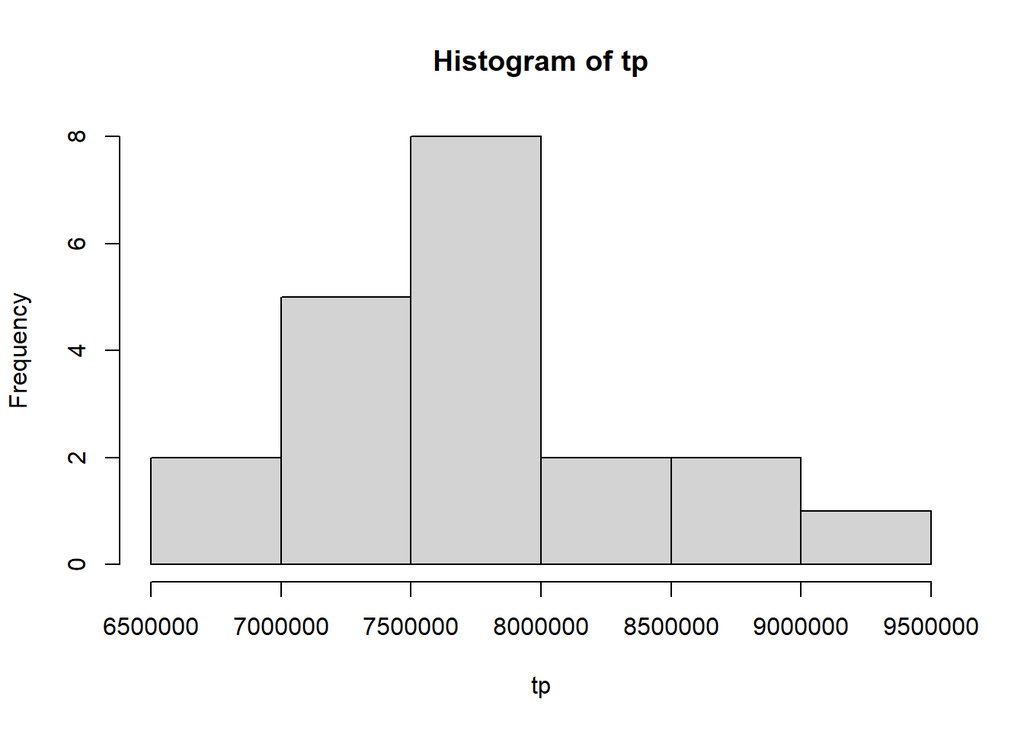

```r
tp<-b$tp
hist(tp)
```

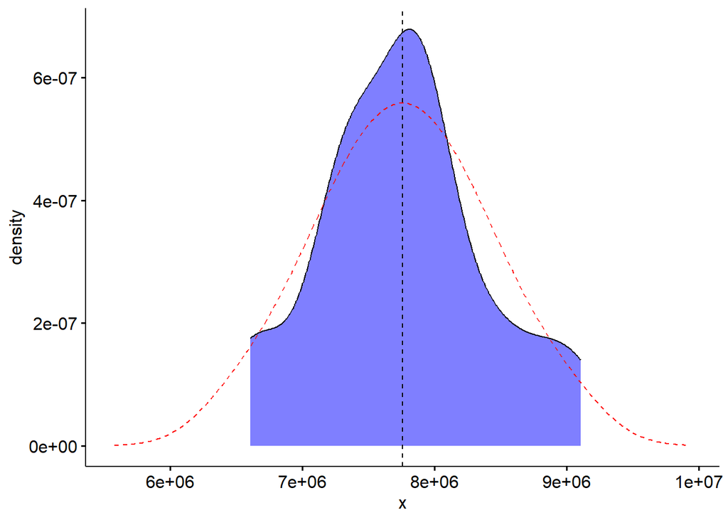

```r
ggdensity(tp, add='mean', fill='blue')+stat_overlay_normal_density(color = "red", linetype = "dashed")
```

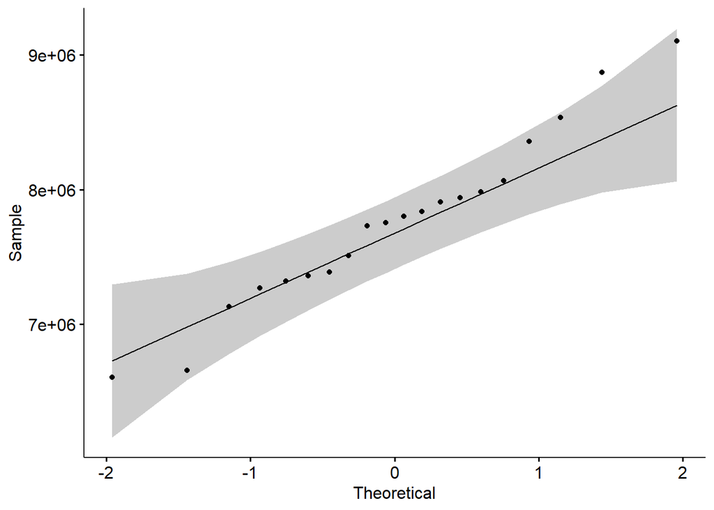

```r
ggqqplot(tp)
```

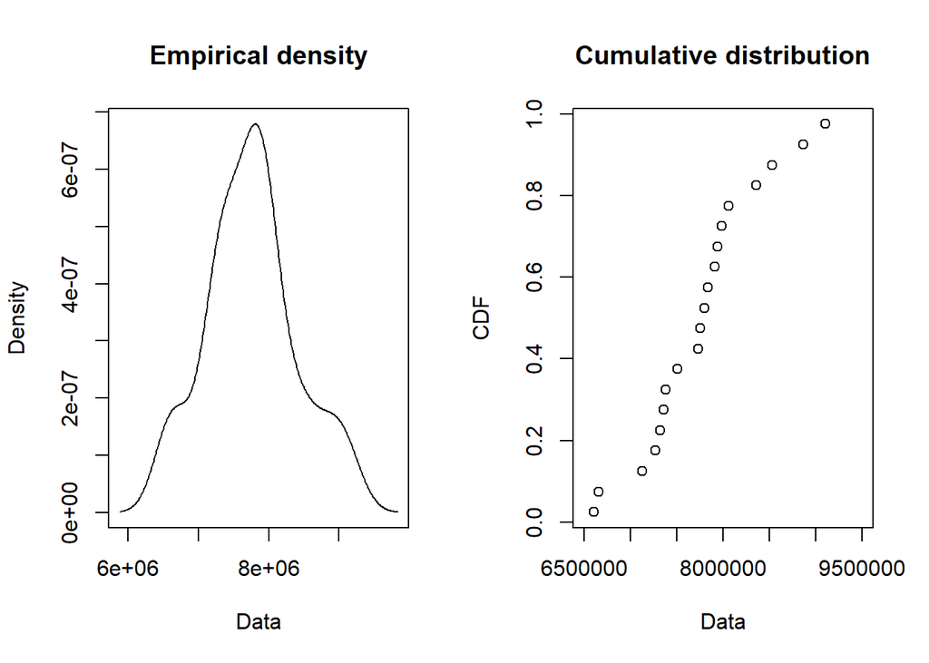

```r
plotdist(tp, histo= FALSE, demp = TRUE)
```

```r
shapiro.test(tp)
```

```
##
##  Shapiro-Wilk normality test
##
## data:  tp
## W = 0.97226, p-value = 0.8017
```

```r
ad.test(tp)
```

```
##
##  Anderson-Darling normality test
##
## data:  tp
## A = 0.25194, p-value = 0.702
```

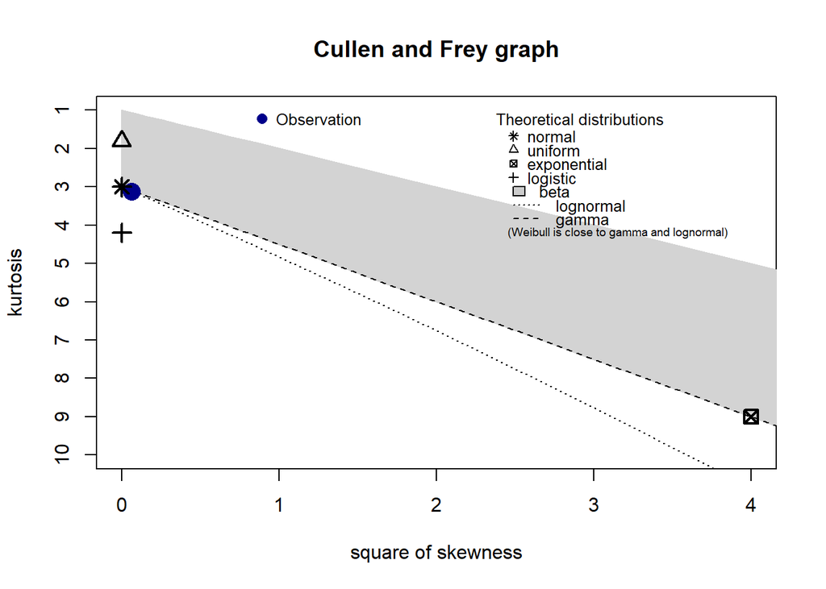

```
## summary statistics
## ------
## min:  6604145   max:  9104597
## median:  7776866
## mean:  7755721
## estimated sd:  646765.6
## estimated skewness:  0.2489908
## estimated kurtosis:  3.122376
```

```r
descdist(data =tp, discrete =FALSE)
```

```r
ntp=fitdist(tp,"norm")
```

#### les tests de normalité de TP sont très bons TP ~ N(mean= 7755721 ,sd= 630389)

## CP1

#### CP1 représente le capital de la banque, qui a connu deux augmentations en 2015 et 2017 avant de se stabiliser à la valeur de 132 405 000 dinars. Nous considérerons donc la valeur de CP1 comme une constante; CP1= 132 405 (en mille dinars)

## CP2

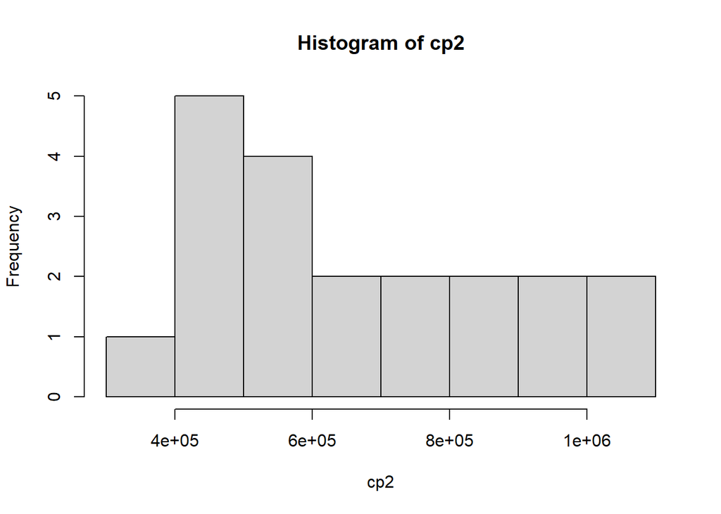

```r
cp2<-b$cp2
hist(cp2)
```

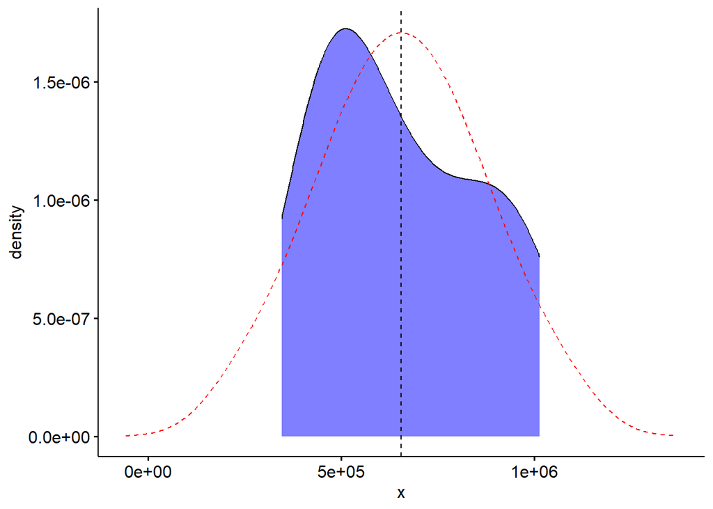

```r
ggdensity(cp2, add='mean', fill='blue')+stat_overlay_normal_density(color = "red", linetype = "dashed")
```

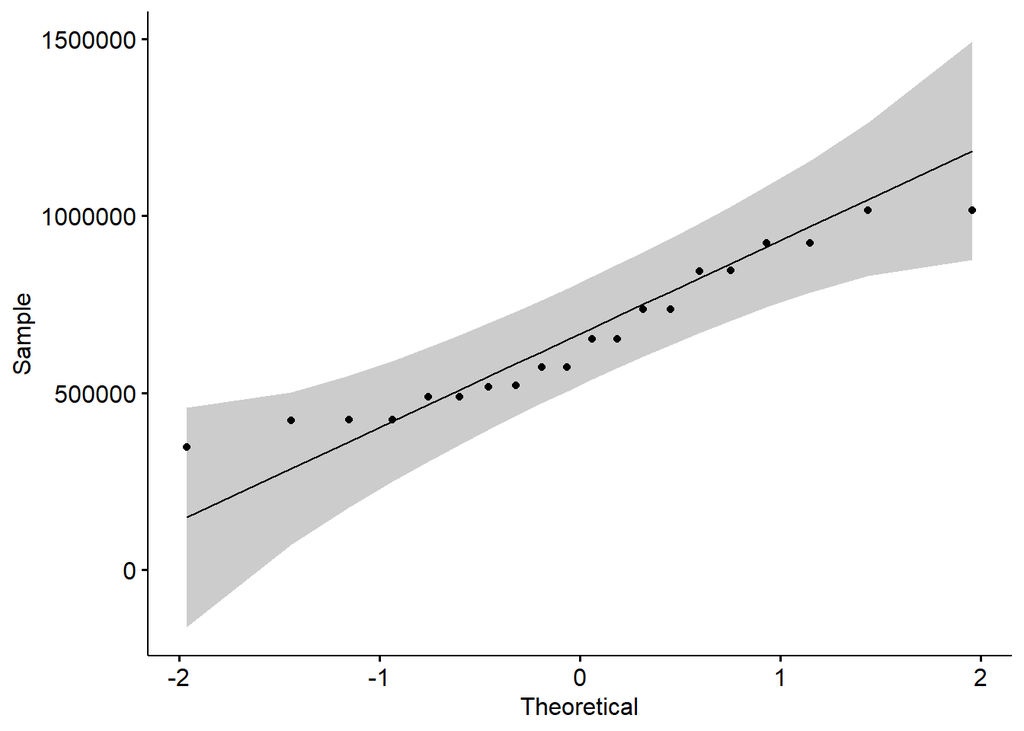

```r
ggqqplot(cp2)
```

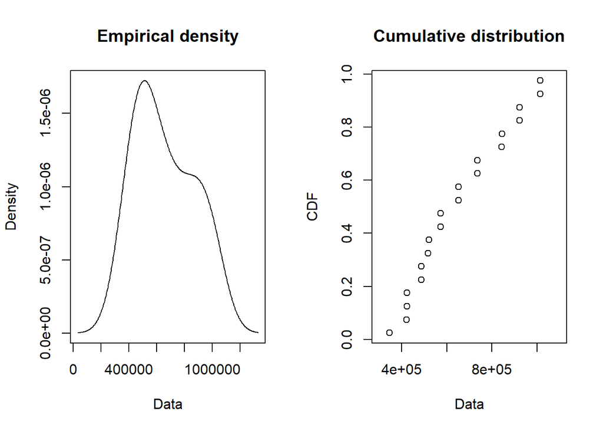

```r
plotdist(cp2, histo= FALSE, demp = TRUE)
```

```r
shapiro.test(cp2)
```

```
##
##  Shapiro-Wilk normality test
##
## data:  cp2
## W = 0.92842, p-value = 0.144
```

```r
ad.test(cp2)
```

```
##
##  Anderson-Darling normality test
##
## data:  cp2
## A = 0.51102, p-value = 0.1728
```

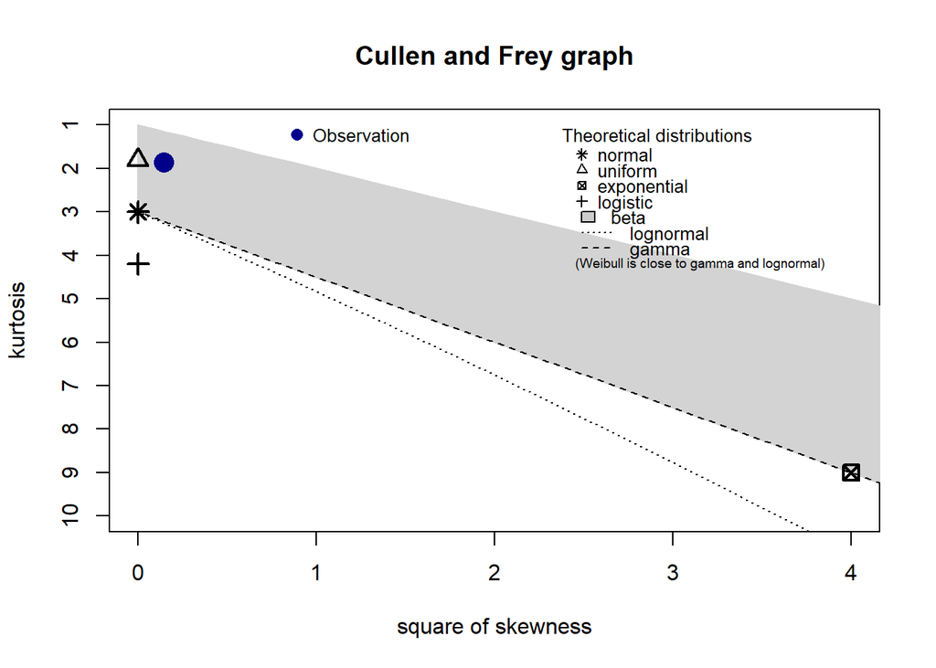

```
## summary statistics
## ------
## min:  346012   max:  1014792
## median:  612345.5
## mean:  655911.1
## estimated sd:  211708.8
## estimated skewness:  0.3813543
## estimated kurtosis:  1.851096
```

```r
descdist(data =cp2, discrete =FALSE)
```

```r
lcp2=fitdist(cp2,"lnorm")
```

#### Conclusion: CP2 ~ LogNormal(mean= 13.344 , sd=0.318), en d’autre termes log(CP2) ~ N(mean= 13.344 , sd=0.318).

## CP4

#### CP4 représente la valeur des autres capitaux propres, cette valeur est inchangée, elle est de l’ordre de 423 000 dinars. Nous considérerons donc la valeur de CP4 comme une constante; CP4= 423 (en mille dinars)

## CP5

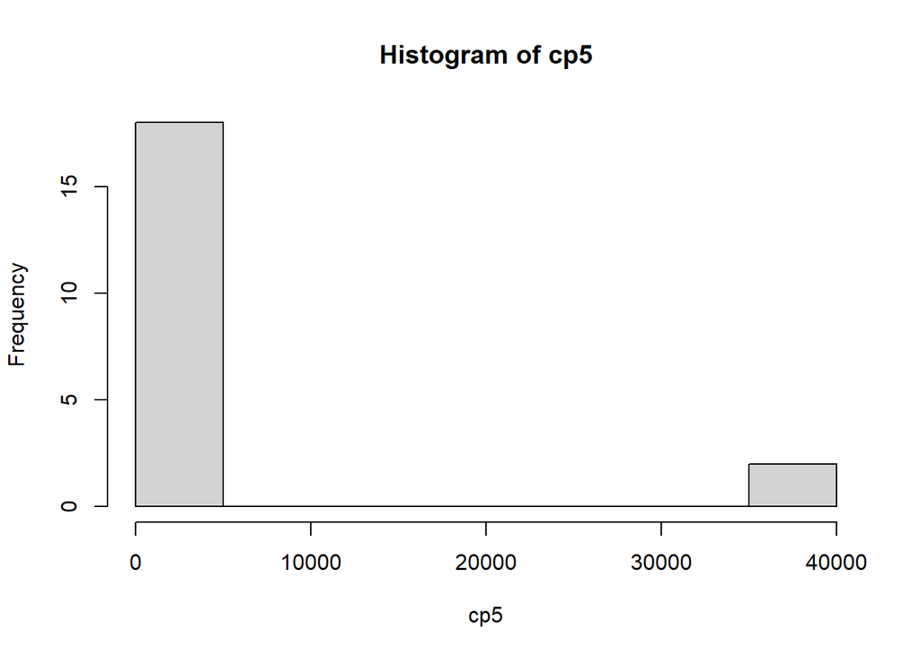

```r
cp5<-b$cp5
hist(cp5)
```

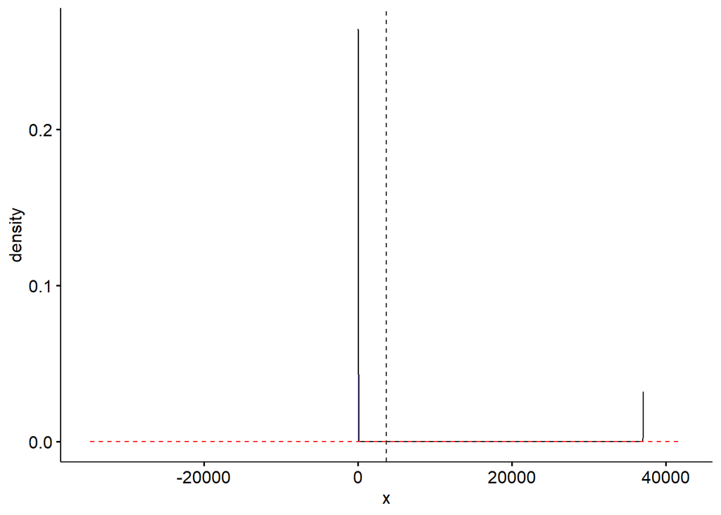

```r
ggdensity(cp5, add='mean', fill='blue')+stat_overlay_normal_density(color = "red", linetype = "dashed")
```

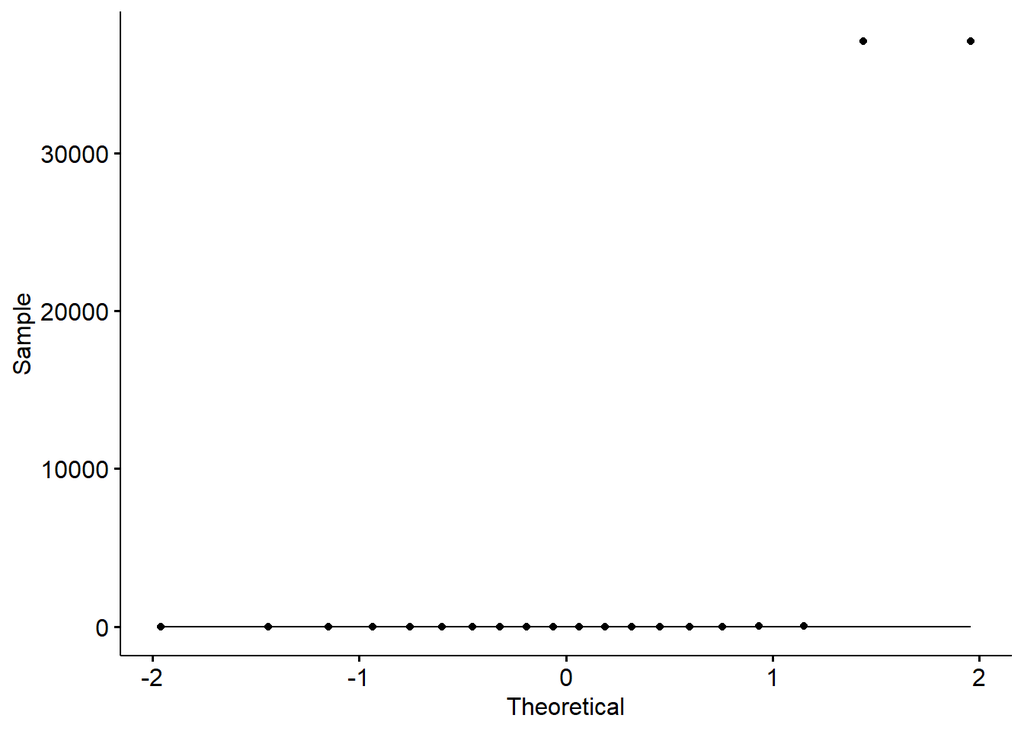

```r
ggqqplot(cp5)
```

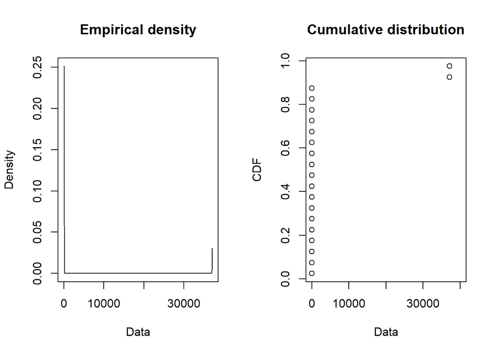

```r
plotdist(cp5, histo= FALSE, demp = TRUE)
```

```r
shapiro.test(cp5)
```

```
##
##  Shapiro-Wilk normality test
##
## data:  cp5
## W = 0.35164, p-value = 1.86e-08
```

```r
ad.test(cp5)
```

```
##
##  Anderson-Darling normality test
##
## data:  cp5
## A = 6.4951, p-value < 2.2e-16
```

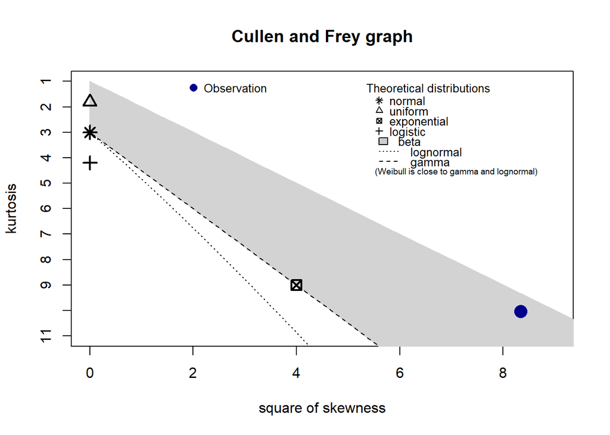

```
## summary statistics
## ------
## min:  0   max:  37091
## median:  5
## mean:  3714.4
## estimated sd:  11414.56
## estimated skewness:  2.887937
## estimated kurtosis:  10.03703
```

```r
descdist(data =cp5, discrete =FALSE)
```

#### Data contains outliers and even after applying log to CP5 or eliminating the oultiers we were unable to fit the data.

#### On a utilisé la fonction normalmixEM du package mixtools pour ajuster CP5

```r
ncp5<-normalmixEM(cp5, k = 2)
```

```
## number of iterations= 4
```

```r
print(ncp5)
```

```
## $x
##  [1]     1     1     5     5 37091 37091    26    26     5     5     5     5
## [13]     4     4     5     5     2     2     0     0
##
## $lambda
## [1] 0.7999767 0.2000233
##
## $mu
## [1]     3.375025 18556.336984
##
## $sigma
## [1]     1.932439 18532.502611
##
## $loglik
## [1] -88.23612
##
## $posterior
##             comp.1       comp.2
##  [1,] 9.999664e-01 3.361101e-05
##  [2,] 9.999664e-01 3.361101e-05
##  [3,] 9.999775e-01 2.249685e-05
##  [4,] 9.999775e-01 2.249685e-05
##  [5,] 0.000000e+00 1.000000e+00
##  [6,] 0.000000e+00 1.000000e+00
##  [7,] 1.084010e-25 1.000000e+00
##  [8,] 1.084010e-25 1.000000e+00
##  [9,] 9.999775e-01 2.249685e-05
## [10,] 9.999775e-01 2.249685e-05
## [11,] 9.999775e-01 2.249685e-05
## [12,] 9.999775e-01 2.249685e-05
## [13,] 9.999834e-01 1.664440e-05
## [14,] 9.999834e-01 1.664440e-05
## [15,] 9.999775e-01 2.249685e-05
## [16,] 9.999775e-01 2.249685e-05
## [17,] 9.999797e-01 2.034459e-05
## [18,] 9.999797e-01 2.034459e-05
## [19,] 9.999274e-01 7.257734e-05
## [20,] 9.999274e-01 7.257734e-05
##
## $all.loglik
## [1] -144.04893  -94.59530  -88.79941  -88.23612  -88.23612
##
## $restarts
## [1] 0
##
## $ft
## [1] "normalmixEM"
##
## attr(,"class")
## [1] "mixEM"
```

#### La fonction normalmixEM() a divisé les données en deux sous groupes de données, chaque groupe de données suit une loi normale:

#### Le premier groupe ~ N1($\mu_1$=3.375025,$\sigma_1$=1.932439) avec un poids $\lambda_1$=0.7999767 et le deuxième ~ N2($\mu_2$=18556.336954,$\sigma_2$=18532.502611) avec un poids $\lambda_2$= 0.2000233.

#### Ainsi la variable CP5 suit une loi qu’on note L dont la pdf f est donnée par:

$$\begin{equation}
f(x) = \lambda_1 \cdot f_1(x) + \lambda_2 \cdot f_2(x)
\end{equation}$$
#### avec:
$$\begin{equation}
f_i(x; \mu_i, \sigma_i) = \frac{1}{\sigma_i \sqrt{2\pi}} \cdot
e^{-\frac{(x - \mu_i)^2}{2\sigma_i^2}}
\end{equation}$$

#### Malgrè l’identification de la loi de CP5 sa manipulation n’est pas pratique.

#### Approche metier CP5: Résultats reportés?

## CP6

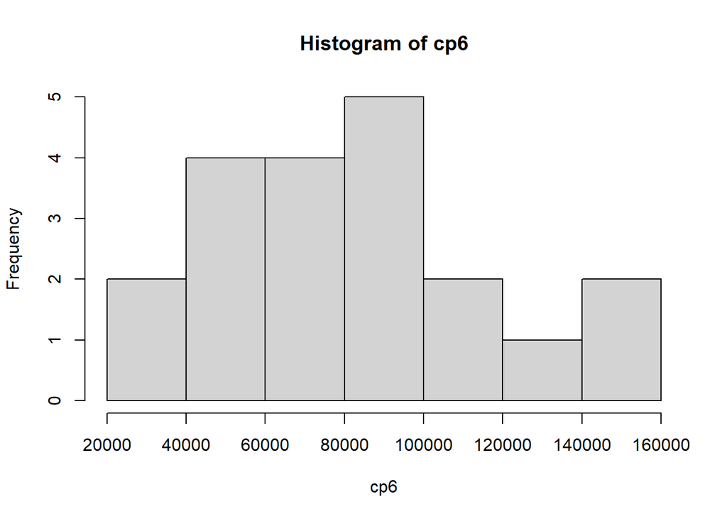

```r
cp6<-b$cp6
hist(cp6)
```

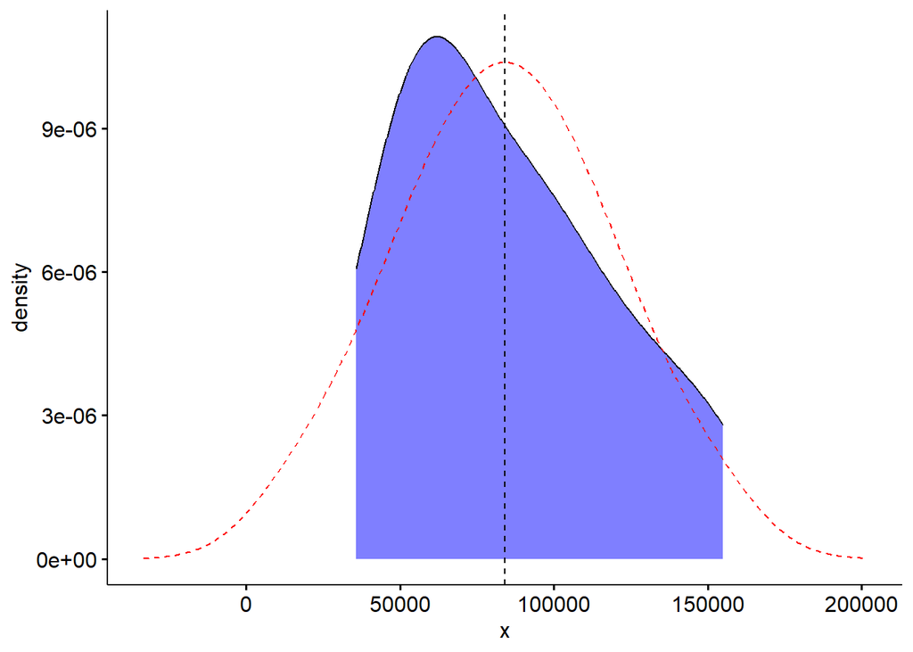

```r
ggdensity(cp6, add='mean', fill='blue')+stat_overlay_normal_density(color = "red", linetype = "dashed")
```